# Populated Pre-Analysis Plan for ‘Feminized victimhood: The political consequences of Global South vulnerability in climate policy discourse’

Leonardo Arriola, Allison Grossman, and Alyssa Heinze

2025-09-12

# Descriptives, treatment assignment, compliance and balance

## Descriptives

|  |  | Mean | SD | N | Percent |
| --- | --- | --- | --- | --- | --- |
| age | 18-24 years old |  |  | 174 | 8.61 |
|  | 25-34 years old |  |  | 320 | 15.83 |
|  | 35-44 years old |  |  | 380 | 18.80 |
|  | 45-54 years old |  |  | 437 | 21.62 |
|  | 55-64 years old |  |  | 400 | 19.79 |
|  | 65-74 years old |  |  | 253 | 12.52 |
|  | 75+ years old |  |  | 57 | 2.82 |
|  | ambivalent_sexism_index | 3.34 | 0.63 | 2021 | 100.00 |
|  | pro_sociality_index | 3.34 | 0.72 | 2021 | 100.00 |
| climate_beliefs | A great deal |  |  | 396 | 19.59 |
|  | A little |  |  | 250 | 12.37 |
|  | A lot |  |  | 632 | 31.27 |
|  | Don't know |  |  | 46 | 2.28 |
|  | Moderately |  |  | 604 | 29.89 |
|  | Not at all |  |  | 93 | 4.60 |
| trust_government | Don't know |  |  | 190 | 9.40 |
|  | Just about always |  |  | 135 | 6.68 |
|  | Most of the time |  |  | 508 | 25.14 |
|  | Only some of the time |  |  | 1188 | 58.78 |
| male | 0 |  |  | 1014 | 50.17 |
|  | 1 |  |  | 1006 | 49.78 |
| has_children | 0 |  |  | 673 | 33.30 |
|  | 1 |  |  | 1348 | 66.70 |
| religiosity | 0 |  |  | 854 | 42.26 |
|  | 1 |  |  | 540 | 26.72 |
|  | 2 |  |  | 378 | 18.70 |
|  | 3 |  |  | 104 | 5.15 |
|  | 4 |  |  | 114 | 5.64 |
|  | 5 |  |  | 31 | 1.53 |
| owner_domicile | 0 |  |  | 741 | 36.67 |
|  | 1 |  |  | 1229 | 60.81 |
| participated_protest_last_12_months | 0 |  |  | 1618 | 80.06 |
|  | 1 |  |  | 403 | 19.94 |
| demanded_action_last_12_months | 0 |  |  | 1613 | 79.81 |
|  | 1 |  |  | 408 | 20.19 |
| employment | A homemaker or stay-at-home parent |  |  | 61 | 3.02 |
|  | Other: |  |  | 24 | 1.19 |
|  | Retired |  |  | 381 | 18.85 |
|  | Student |  |  | 69 | 3.41 |
|  | Unemployed and looking for work |  |  | 86 | 4.26 |
|  | Working full-time |  |  | 1231 | 60.91 |
|  | Working part-time |  |  | 169 | 8.36 |
| education | Informal education only (including Koranic school) |  |  | 34 | 1.68 |
|  | No formal education |  |  | 30 | 1.48 |
|  | Post-university |  |  | 135 | 6.68 |
|  | Primary school |  |  | 42 | 2.08 |
|  | Secondary school |  |  | 867 | 42.90 |
|  | University |  |  | 913 | 45.18 |
| nationality | East Asia |  |  | 6 | 0.30 |
|  | Eastern Europe (outside France) |  |  | 36 | 1.78 |
|  | France |  |  | 1809 | 89.51 |
|  | Latin America |  |  | 7 | 0.35 |
|  | North Africa |  |  | 65 | 3.22 |
|  | North America |  |  | 3 | 0.15 |
|  | Oceania |  |  | 3 | 0.15 |
|  | South Asia |  |  | 5 | 0.25 |
|  | Sub-Saharan Africa |  |  | 21 | 1.04 |
|  | Western Europe (outside France) |  |  | 66 | 3.27 |

|  |  | Mean | SD | N | Percent |
| --- | --- | --- | --- | --- | --- |
| age | 18-24 years old |  |  | 541 | 31.64 |
|  | 25-34 years old |  |  | 665 | 38.89 |
|  | 35-44 years old |  |  | 329 | 19.24 |
|  | 45-54 years old |  |  | 142 | 8.30 |
|  | 55-64 years old |  |  | 32 | 1.87 |
|  | 75+ years old |  |  | 1 | 0.06 |
|  | ambivalent_sexism_index | 3.62 | 0.67 | 1710 | 100.00 |
|  | pro_sociality_index | 3.90 | 0.69 | 1710 | 100.00 |
| climate_beliefs | A great deal |  |  | 407 | 23.80 |
|  | A little |  |  | 284 | 16.61 |
|  | A lot |  |  | 584 | 34.15 |
|  | Don't know |  |  | 45 | 2.63 |
|  | Moderately |  |  | 311 | 18.19 |
|  | Not at all |  |  | 79 | 4.62 |
| trust_government | Don't know |  |  | 328 | 19.18 |
|  | Just about always |  |  | 248 | 14.50 |
|  | Most of the time |  |  | 542 | 31.70 |
|  | Only some of the time |  |  | 592 | 34.62 |
| male | 0 |  |  | 687 | 40.18 |
|  | 1 |  |  | 1007 | 58.89 |
| has_children | 0 |  |  | 904 | 52.87 |
|  | 1 |  |  | 806 | 47.13 |
| religiosity | 0 |  |  | 116 | 6.78 |
|  | 1 |  |  | 262 | 15.32 |
|  | 2 |  |  | 311 | 18.19 |
|  | 3 |  |  | 272 | 15.91 |
|  | 4 |  |  | 443 | 25.91 |
|  | 5 |  |  | 306 | 17.89 |
| owner_domicile | 0 |  |  | 1196 | 69.94 |
|  | 1 |  |  | 307 | 17.95 |
| participated_protest_last_12_months | 0 |  |  | 1267 | 74.09 |
|  | 1 |  |  | 443 | 25.91 |
| demanded_action_last_12_months | 0 |  |  | 1314 | 76.84 |
|  | 1 |  |  | 396 | 23.16 |
| employment | A homemaker or stay-at-home parent |  |  | 33 | 1.93 |
|  | Other: |  |  | 28 | 1.64 |
|  | Retired |  |  | 9 | 0.53 |
|  | Student |  |  | 376 | 21.99 |
|  | Unemployed and looking for work |  |  | 235 | 13.74 |
|  | Working full-time |  |  | 710 | 41.52 |
|  | Working part-time |  |  | 319 | 18.65 |
| education | Informal education only (including Koranic school) |  |  | 9 | 0.53 |
|  | No formal education |  |  | 24 | 1.40 |
|  | Post-university |  |  | 87 | 5.09 |
|  | Primary school |  |  | 33 | 1.93 |
|  | Secondary school |  |  | 407 | 23.80 |
|  | University |  |  | 1150 | 67.25 |
| ethnicity | Abbey |  |  | 59 | 3.45 |
|  | Abron |  |  | 43 | 2.51 |
|  | Adjoukrou |  |  | 72 | 4.21 |
|  | Agni |  |  | 169 | 9.88 |
|  | Attié |  |  | 95 | 5.56 |
|  | Avikam |  |  | 14 | 0.82 |
|  | Bambara |  |  | 39 | 2.28 |
|  | Baoulé |  |  | 415 | 24.27 |
|  | Bété |  |  | 123 | 7.19 |
|  | Dida |  |  | 39 | 2.28 |
|  | Dioula |  |  | 86 | 5.03 |
|  | Don't know |  |  | 42 | 2.46 |
|  | Godié |  |  | 11 | 0.64 |
|  | Gouro |  |  | 48 | 2.81 |
|  | Guéré |  |  | 58 | 3.39 |
|  | Koulango |  |  | 25 | 1.46 |
|  | Kroumen |  |  | 14 | 0.82 |
|  | Lobi |  |  | 4 | 0.23 |
|  | Malinké/Maninka |  |  | 62 | 3.63 |
|  | Only Ivoirian (do not identify in these terms) |  |  | 106 | 6.20 |
|  | Senoufo |  |  | 124 | 7.25 |
|  | Yacouba |  |  | 62 | 3.63 |

## Treatment assignment and compliance

| treatment | N | Percent |
| --- | --- | --- |
| Man_agent | 937 | 25.11 |
| Man_victim | 933 | 25.01 |
| Woman_agent | 924 | 24.77 |
| Woman_victim | 937 | 25.11 |

| treatment | photo_recall Man holding bucket | photo_recall Man holding sign | photo_recall Woman holding bucket | photo_recall Woman holding sign | gender_photo Don’t know | gender_photo Man | gender_photo There was no person in the photo | gender_photo Woman | victim_agent_photo Don’t know | victim_agent_photo The person was a victim of climate change | victim_agent_photo The person was mobilizing to combat climate change |
| --- | --- | --- | --- | --- | --- | --- | --- | --- | --- | --- | --- |
| Man_agent | 36.00 | 839.00 | 14.00 | 48.00 | 12.00 | 867.00 | 3.00 | 55.00 | 35.00 | 453.00 | 449.00 |
| Man_victim | 702.00 | 40.00 | 166.00 | 25.00 | 6.00 | 743.00 | 3.00 | 181.00 | 35.00 | 796.00 | 102.00 |
| Woman_agent | 7.00 | 82.00 | 28.00 | 807.00 | 3.00 | 79.00 | 3.00 | 839.00 | 20.00 | 319.00 | 585.00 |
| Woman_victim | 20.00 | 20.00 | 849.00 | 48.00 | 4.00 | 30.00 | 4.00 | 899.00 | 44.00 | 791.00 | 102.00 |

## Balance

|  |  | Man_agent (N=937) Mean | Man_agent (N=937) Std. Dev. | Man_victim (N=933) Mean | Man_victim (N=933) Std. Dev. | Woman_agent (N=924) Mean | Woman_agent (N=924) Std. Dev. | Woman_victim (N=937) Mean | Woman_victim (N=937) Std. Dev. |
| --- | --- | --- | --- | --- | --- | --- | --- | --- | --- |
| male |  | 0.6 | 0.5 | 0.5 | 0.5 | 0.5 | 0.5 | 0.5 | 0.5 |
| has_children |  | 0.6 | 0.5 | 0.6 | 0.5 | 0.6 | 0.5 | 0.6 | 0.5 |
| religiosity |  | 2.0 | 1.6 | 1.9 | 1.6 | 2.0 | 1.7 | 1.9 | 1.7 |
| owner_domicile |  | 0.4 | 0.5 | 0.4 | 0.5 | 0.4 | 0.5 | 0.4 | 0.5 |
| ambivalent_sexism_index |  | 3.5 | 0.6 | 3.4 | 0.7 | 3.5 | 0.7 | 3.5 | 0.7 |
| pro_sociality_index |  | 3.6 | 0.8 | 3.6 | 0.8 | 3.6 | 0.8 | 3.6 | 0.8 |
| participated_protest_last_12_months |  | 0.2 | 0.4 | 0.2 | 0.4 | 0.2 | 0.4 | 0.2 | 0.4 |
| demanded_action_last_12_months |  | 0.2 | 0.4 | 0.2 | 0.4 | 0.2 | 0.4 | 0.2 | 0.4 |
|  |  | N | Pct. | N | Pct. | N | Pct. | N | Pct. |
| age | 18-24 years old | 183 | 19.5 | 179 | 19.2 | 191 | 20.7 | 162 | 17.3 |
|  | 25-34 years old | 256 | 27.3 | 237 | 25.4 | 237 | 25.6 | 255 | 27.2 |
|  | 35-44 years old | 177 | 18.9 | 180 | 19.3 | 178 | 19.3 | 174 | 18.6 |
|  | 45-54 years old | 141 | 15.0 | 142 | 15.2 | 133 | 14.4 | 163 | 17.4 |
|  | 55-64 years old | 108 | 11.5 | 109 | 11.7 | 108 | 11.7 | 107 | 11.4 |
|  | 65-74 years old | 66 | 7.0 | 65 | 7.0 | 65 | 7.0 | 57 | 6.1 |
|  | 75+ years old | 6 | 0.6 | 21 | 2.3 | 12 | 1.3 | 19 | 2.0 |
| employment | A homemaker or stay-at-home parent | 21 | 2.2 | 26 | 2.8 | 20 | 2.2 | 27 | 2.9 |
|  | Other: | 12 | 1.3 | 14 | 1.5 | 11 | 1.2 | 15 | 1.6 |
|  | Retired | 92 | 9.8 | 111 | 11.9 | 92 | 10.0 | 95 | 10.1 |
|  | Student | 121 | 12.9 | 100 | 10.7 | 115 | 12.4 | 109 | 11.6 |
|  | Unemployed and looking for work | 78 | 8.3 | 80 | 8.6 | 91 | 9.8 | 72 | 7.7 |
|  | Working full-time | 492 | 52.5 | 488 | 52.3 | 483 | 52.3 | 478 | 51.0 |
|  | Working part-time | 121 | 12.9 | 114 | 12.2 | 112 | 12.1 | 141 | 15.0 |
| education | Informal education only (including Koranic school) | 13 | 1.4 | 10 | 1.1 | 9 | 1.0 | 11 | 1.2 |
|  | No formal education | 14 | 1.5 | 10 | 1.1 | 12 | 1.3 | 18 | 1.9 |
|  | Post-university | 66 | 7.0 | 45 | 4.8 | 61 | 6.6 | 50 | 5.3 |
|  | Primary school | 20 | 2.1 | 21 | 2.3 | 15 | 1.6 | 19 | 2.0 |
|  | Secondary school | 326 | 34.8 | 315 | 33.8 | 301 | 32.6 | 332 | 35.4 |
|  | University | 498 | 53.1 | 532 | 57.0 | 526 | 56.9 | 507 | 54.1 |
| nationality | East Asia | 1 | 0.1 | 1 | 0.1 | 3 | 0.3 | 1 | 0.1 |
|  | Eastern Europe (outside France) | 5 | 0.5 | 13 | 1.4 | 8 | 0.9 | 10 | 1.1 |
|  | France | 451 | 48.1 | 460 | 49.3 | 442 | 47.8 | 456 | 48.7 |
|  | Latin America | 3 | 0.3 | 1 | 0.1 | 1 | 0.1 | 2 | 0.2 |
|  | North Africa | 22 | 2.3 | 12 | 1.3 | 15 | 1.6 | 16 | 1.7 |
|  | North America | 1 | 0.1 | 1 | 0.1 | 0 | 0.0 | 1 | 0.1 |
|  | Oceania | 0 | 0.0 | 0 | 0.0 | 1 | 0.1 | 2 | 0.2 |
|  | South Asia | 2 | 0.2 | 2 | 0.2 | 1 | 0.1 | 0 | 0.0 |
|  | Sub-Saharan Africa | 8 | 0.9 | 6 | 0.6 | 3 | 0.3 | 4 | 0.4 |
|  | Western Europe (outside France) | 14 | 1.5 | 15 | 1.6 | 20 | 2.2 | 17 | 1.8 |
|  | NA | 430 | 45.9 | 422 | 45.2 | 430 | 46.5 | 428 | 45.7 |
| ethnicity | Abbey | 12 | 1.3 | 12 | 1.3 | 14 | 1.5 | 21 | 2.2 |
|  | Abron | 12 | 1.3 | 12 | 1.3 | 7 | 0.8 | 12 | 1.3 |
|  | Adjoukrou | 15 | 1.6 | 22 | 2.4 | 23 | 2.5 | 12 | 1.3 |
|  | Agni | 47 | 5.0 | 40 | 4.3 | 45 | 4.9 | 37 | 3.9 |
|  | Attié | 28 | 3.0 | 28 | 3.0 | 18 | 1.9 | 21 | 2.2 |
|  | Avikam | 4 | 0.4 | 3 | 0.3 | 7 | 0.8 | 0 | 0.0 |
|  | Bambara | 10 | 1.1 | 8 | 0.9 | 14 | 1.5 | 7 | 0.7 |
|  | Baoulé | 105 | 11.2 | 94 | 10.1 | 107 | 11.6 | 109 | 11.6 |
|  | Bété | 24 | 2.6 | 33 | 3.5 | 28 | 3.0 | 38 | 4.1 |
|  | Dida | 7 | 0.7 | 9 | 1.0 | 12 | 1.3 | 11 | 1.2 |
|  | Dioula | 24 | 2.6 | 16 | 1.7 | 24 | 2.6 | 22 | 2.3 |
|  | Don't know | 6 | 0.6 | 13 | 1.4 | 11 | 1.2 | 12 | 1.3 |
|  | Godié | 3 | 0.3 | 1 | 0.1 | 1 | 0.1 | 6 | 0.6 |
|  | Gouro | 6 | 0.6 | 17 | 1.8 | 11 | 1.2 | 14 | 1.5 |
|  | Guéré | 16 | 1.7 | 12 | 1.3 | 14 | 1.5 | 16 | 1.7 |
|  | Koulango | 6 | 0.6 | 12 | 1.3 | 4 | 0.4 | 3 | 0.3 |
|  | Kroumen | 4 | 0.4 | 3 | 0.3 | 4 | 0.4 | 3 | 0.3 |
|  | Lobi | 3 | 0.3 | 1 | 0.1 | 0 | 0.0 | 0 | 0.0 |
|  | Malinké/Maninka | 14 | 1.5 | 16 | 1.7 | 14 | 1.5 | 18 | 1.9 |
|  | Only Ivoirian (do not identify in these terms) | 30 | 3.2 | 24 | 2.6 | 24 | 2.6 | 28 | 3.0 |
|  | Senoufo | 37 | 3.9 | 30 | 3.2 | 36 | 3.9 | 21 | 2.2 |
|  | Yacouba | 17 | 1.8 | 16 | 1.7 | 12 | 1.3 | 17 | 1.8 |
|  | NA | 507 | 54.1 | 511 | 54.8 | 494 | 53.5 | 509 | 54.3 |
| climate_beliefs | A great deal | 187 | 20.0 | 192 | 20.6 | 201 | 21.8 | 223 | 23.8 |
|  | A little | 127 | 13.6 | 141 | 15.1 | 140 | 15.2 | 126 | 13.4 |
|  | A lot | 321 | 34.3 | 317 | 34.0 | 296 | 32.0 | 282 | 30.1 |
|  | Don't know | 28 | 3.0 | 24 | 2.6 | 20 | 2.2 | 19 | 2.0 |
|  | Moderately | 230 | 24.5 | 223 | 23.9 | 224 | 24.2 | 238 | 25.4 |
|  | Not at all | 44 | 4.7 | 36 | 3.9 | 43 | 4.7 | 49 | 5.2 |
| trust_government | Don't know | 124 | 13.2 | 123 | 13.2 | 143 | 15.5 | 128 | 13.7 |
|  | Just about always | 85 | 9.1 | 94 | 10.1 | 102 | 11.0 | 102 | 10.9 |
|  | Most of the time | 269 | 28.7 | 256 | 27.4 | 269 | 29.1 | 256 | 27.3 |
|  | Only some of the time | 459 | 49.0 | 460 | 49.3 | 410 | 44.4 | 451 | 48.1 |

|  | Man victim | Man agent | Woman victim | Woman agent |
| --- | --- | --- | --- | --- |
| (Intercept) | 0.406*** | 0.089 | 0.294** | 0.211* |
|  | (0.097) | (0.099) | (0.103) | (0.100) |
| male | 0.002 | 0.011 | −0.022 | 0.009 |
|  | (0.015) | (0.015) | (0.015) | (0.015) |
| age25-34 years old | −0.040 | 0.036 | 0.038 | −0.035 |
|  | (0.027) | (0.027) | (0.027) | (0.027) |
| age35-44 years old | −0.030 | 0.016 | 0.035 | −0.021 |
|  | (0.030) | (0.029) | (0.029) | (0.030) |
| age45-54 years old | −0.043 | 0.010 | 0.069* | −0.036 |
|  | (0.032) | (0.031) | (0.032) | (0.031) |
| age55-64 years old | −0.051 | 0.017 | 0.034 | −0.001 |
|  | (0.035) | (0.035) | (0.035) | (0.035) |
| age65-74 years old | −0.076 | 0.020 | 0.021 | 0.036 |
|  | (0.053) | (0.055) | (0.054) | (0.051) |
| age75+ years old | 0.028 | −0.147* | 0.134+ | −0.015 |
|  | (0.079) | (0.066) | (0.079) | (0.069) |
| employmentOther × | 0.048 | −0.021 | −0.005 | −0.021 |
|  | (0.082) | (0.075) | (0.083) | (0.075) |
| employmentRetired | 0.051 | 0.018 | −0.042 | −0.028 |
|  | (0.062) | (0.062) | (0.065) | (0.059) |
| employmentStudent | −0.062 | 0.049 | −0.007 | 0.019 |
|  | (0.055) | (0.055) | (0.058) | (0.056) |
| employmentUnemployed and looking for work | 0.003 | 0.011 | −0.076 | 0.062 |
|  | (0.054) | (0.053) | (0.056) | (0.054) |
| employmentWorking full-time | 0.002 | 0.017 | −0.036 | 0.017 |
|  | (0.048) | (0.047) | (0.051) | (0.047) |
| employmentWorking part-time | −0.014 | 0.016 | −0.000 | −0.002 |
|  | (0.051) | (0.050) | (0.054) | (0.050) |
| educationNo formal education | −0.068 | 0.006 | 0.036 | 0.026 |
|  | (0.088) | (0.094) | (0.097) | (0.089) |
| educationPost-university | −0.030 | 0.005 | −0.065 | 0.091 |
|  | (0.075) | (0.079) | (0.080) | (0.072) |
| educationPrimary school | 0.032 | −0.001 | −0.040 | 0.009 |
|  | (0.088) | (0.089) | (0.091) | (0.082) |
| educationSecondary school | 0.005 | −0.020 | −0.028 | 0.043 |
|  | (0.071) | (0.074) | (0.076) | (0.067) |
| educationUniversity | 0.027 | −0.048 | −0.042 | 0.063 |
|  | (0.071) | (0.073) | (0.075) | (0.066) |
| has_children | −0.010 | −0.002 | 0.002 | 0.010 |
|  | (0.018) | (0.017) | (0.018) | (0.018) |
| religiosity | −0.005 | 0.001 | −0.000 | 0.004 |
|  | (0.005) | (0.005) | (0.005) | (0.005) |
| owner_domicile | −0.008 | 0.014 | −0.013 | 0.007 |
|  | (0.017) | (0.017) | (0.017) | (0.017) |
| ambivalent_sexism_index | −0.030* | 0.025* | −0.002 | 0.007 |
|  | (0.012) | (0.012) | (0.012) | (0.012) |
| climate_beliefsA little | 0.002 | 0.011 | −0.033 | 0.019 |
|  | (0.026) | (0.025) | (0.026) | (0.026) |
| climate_beliefsA lot | 0.016 | 0.034+ | −0.041* | −0.009 |
|  | (0.021) | (0.020) | (0.021) | (0.020) |
| climate_beliefsDon't know | −0.016 | 0.094+ | −0.045 | −0.032 |
|  | (0.053) | (0.056) | (0.051) | (0.051) |
| climate_beliefsModerately | −0.014 | 0.023 | −0.007 | −0.002 |
|  | (0.022) | (0.022) | (0.023) | (0.022) |
| climate_beliefsNot at all | −0.048 | 0.018 | 0.010 | 0.019 |
|  | (0.037) | (0.039) | (0.041) | (0.039) |
| pro_sociality_index | −0.010 | 0.008 | 0.009 | −0.007 |
|  | (0.011) | (0.011) | (0.011) | (0.011) |
| trust_governmentJust about always | 0.015 | −0.025 | 0.029 | −0.018 |
|  | (0.031) | (0.031) | (0.032) | (0.033) |
| trust_governmentMost of the time | 0.006 | 0.022 | −0.000 | −0.028 |
|  | (0.025) | (0.026) | (0.026) | (0.026) |
| trust_governmentOnly some of the time | 0.026 | 0.019 | 0.007 | −0.052* |
|  | (0.023) | (0.024) | (0.024) | (0.024) |
| participated_protest_last_12_months | 0.026 | 0.007 | −0.026 | −0.007 |
|  | (0.020) | (0.020) | (0.020) | (0.020) |
| demanded_action_last_12_months | −0.000 | −0.012 | −0.002 | 0.014 |
|  | (0.020) | (0.020) | (0.020) | (0.020) |
| Num.Obs. | 3459 | 3459 | 3459 | 3459 |
| R2 | 0.010 | 0.009 | 0.009 | 0.007 |
| F.statistic | 1.126 | 1.066 | 0.936 | 0.698 |
| F.p.value | 0.285 | 0.367 | 0.572 | 0.901 |

+ p < 0.1, * p < 0.05, ** p < 0.01, *** p < 0.001  
Each model is a linear regression of each treatment group indicator on covariates. All regressions use robust standard errors.

# Main hypothesis 1 (M1).

Feminization of climate change communication will politically demobilize Ivorian citizens. We expect that this will have no effect or a positive effect on French citizens. We present country-wise regressions in the main paper and pooled regressions across the sample in the appendix.

|  | CDI, unadjusted | CDI, adjusted | FR, unadjusted | FR, adjusted | Pooled, unadjusted | Pooled, adjusted |
| --- | --- | --- | --- | --- | --- | --- |
| (Intercept) | −0.406*** | 3.357*** | 0.326*** | 1.978*** | −0.009 | 3.314*** |
|  | (0.048) | (0.597) | (0.044) | (0.541) | (0.034) | (0.291) |
| treatment_female | 0.020 | 0.062 | 0.024 | 0.007 | 0.019 | 0.027 |
|  | (0.067) | (0.066) | (0.063) | (0.056) | (0.047) | (0.043) |
| male |  | −0.170* |  | 0.027 |  | −0.031 |
|  |  | (0.076) |  | (0.060) |  | (0.045) |
| age25-34 years old |  | −0.352*** |  | −0.089 |  | −0.278*** |
|  |  | (0.103) |  | (0.137) |  | (0.081) |
| age35-44 years old |  | −0.389** |  | −0.144 |  | −0.196* |
|  |  | (0.122) |  | (0.139) |  | (0.088) |
| age45-54 years old |  | −0.484** |  | −0.113 |  | −0.113 |
|  |  | (0.162) |  | (0.141) |  | (0.094) |
| age55-64 years old |  | −0.185 |  | −0.394** |  | −0.230* |
|  |  | (0.345) |  | (0.144) |  | (0.105) |
| age75+ years old |  | 0.345 |  | −0.291 |  | −0.026 |
|  |  | (0.343) |  | (0.223) |  | (0.204) |
| employmentOther × |  | −0.145 |  | 0.295 |  | −0.083 |
|  |  | (0.322) |  | (0.237) |  | (0.194) |
| employmentRetired |  | 0.310 |  | 0.316 |  | 0.092 |
|  |  | (0.634) |  | (0.197) |  | (0.175) |
| employmentStudent |  | 0.159 |  | 0.035 |  | 0.181 |
|  |  | (0.256) |  | (0.238) |  | (0.160) |
| employmentUnemployed and looking for work |  | 0.060 |  | 0.412+ |  | 0.193 |
|  |  | (0.253) |  | (0.222) |  | (0.158) |
| employmentWorking full-time |  | 0.020 |  | 0.389* |  | 0.200 |
|  |  | (0.240) |  | (0.166) |  | (0.136) |
| employmentWorking part-time |  | −0.036 |  | 0.484** |  | 0.124 |
|  |  | (0.243) |  | (0.184) |  | (0.143) |
| educationNo formal education |  | −0.520 |  | −0.373 |  | −0.429 |
|  |  | (0.616) |  | (0.328) |  | (0.278) |

[output cut: 102 more lines]

+ p < 0.1, * p < 0.05, ** p < 0.01, *** p < 0.001  
Note: Outcome is a PCA index of the three political mobilization outcomes. Robust SEs.

# Main hypothesis 2 (M2).

Victimization of climate change communication will politically demobilize Global South citizens. We expect that this will have no effect or a positive effect on French citizens. We present country-wise regressions in the main paper and pooled regressions across the sample in the appendix.

|  | CDI, unadjusted | CDI, adjusted | FR, unadjusted | FR, adjusted | Pooled, unadjusted | Pooled, adjusted |
| --- | --- | --- | --- | --- | --- | --- |
| (Intercept) | −0.396*** | 3.357 | 0.316*** | 1.963*** | −0.015 | 3.321*** |
|  | (0.048) |  | (0.043) | (0.539) | (0.033) | (0.292) |
| treatment_victim | 0.001 | 0.040 | 0.043 | 0.030 | 0.029 | 0.011 |
|  | (0.067) |  | (0.063) | (0.056) | (0.047) | (0.043) |
| male |  | −0.170 |  | 0.028 |  | −0.031 |
|  |  |  |  | (0.060) |  | (0.045) |
| age25-34 years old |  | −0.351 |  | −0.088 |  | −0.278*** |
|  |  |  |  | (0.137) |  | (0.081) |
| age35-44 years old |  | −0.390 |  | −0.143 |  | −0.196* |
|  |  |  |  | (0.139) |  | (0.088) |
| age45-54 years old |  | −0.486 |  | −0.113 |  | −0.112 |
|  |  |  |  | (0.141) |  | (0.094) |
| age55-64 years old |  | −0.191 |  | −0.392** |  | −0.228* |
|  |  |  |  | (0.144) |  | (0.105) |
| age75+ years old |  | 0.356 |  | −0.295 |  | −0.024 |
|  |  |  |  | (0.223) |  | (0.204) |
| employmentOther × |  | −0.137 |  | 0.295 |  | −0.084 |
|  |  |  |  | (0.236) |  | (0.194) |
| employmentRetired |  | 0.313 |  | 0.315 |  | 0.091 |
|  |  |  |  | (0.196) |  | (0.175) |
| employmentStudent |  | 0.169 |  | 0.035 |  | 0.182 |
|  |  |  |  | (0.238) |  | (0.160) |
| employmentUnemployed and looking for work |  | 0.067 |  | 0.415+ |  | 0.194 |
|  |  |  |  | (0.222) |  | (0.158) |
| employmentWorking full-time |  | 0.027 |  | 0.388* |  | 0.200 |
|  |  |  |  | (0.166) |  | (0.136) |
| employmentWorking part-time |  | −0.030 |  | 0.485** |  | 0.125 |
|  |  |  |  | (0.184) |  | (0.143) |
| educationNo formal education |  | −0.516 |  | −0.368 |  | −0.427 |
|  |  |  |  | (0.329) |  | (0.278) |

[output cut: 81 more lines]

+ p < 0.1, * p < 0.05, ** p < 0.01, *** p < 0.001  
Note: Outcome is a PCA index of the three political mobilization outcomes. Robust SEs.

# Main hypothesis 3 (M3).

Feminization of climate change communication will increase support for Global South climate financing among Global North citizens (for all outcomes). We expect the same among Global South citizens but only for 5/6 outcomes. For Global South citizens, we expect the last outcome (willingness to pay) to move in the opposite direction. We present country-wise regressions in the main paper and pooled regressions across the sample in the appendix.

|  | Prefers adaptation finance in poor countries vs. France Unadjusted | Prefers adaptation finance in poor countries vs. France Adjusted | Prefers adaptation finance vs. emergency relief Unadjusted | Prefers adaptation finance vs. emergency relief Adjusted | Prefers gender-based adaptation finance vs. general programming Unadjusted | Prefers gender-based adaptation finance vs. general programming Adjusted | Willingness to sign petition Unadjusted | Willingness to sign petition Adjusted | Clicks to learn more about climate adaptation Unadjusted | Clicks to learn more about climate adaptation Adjusted | Willingness to pay Unadjusted | Willingness to pay Adjusted |
| --- | --- | --- | --- | --- | --- | --- | --- | --- | --- | --- | --- | --- |
| (Intercept) | 0.842*** | 0.559* | 0.445*** | 0.447* | 0.331*** | −0.166 | 0.838*** | 0.496* | 0.103*** | 0.068 | 0.786*** | 0.532*** |
|  | (0.013) | (0.238) | (0.017) | (0.218) | (0.016) | (0.270) | (0.013) | (0.200) | (0.010) | (0.088) | (0.014) | (0.121) |
| treatment_female | −0.015 | −0.015 | −0.004 | −0.005 | 0.136*** | 0.148*** | −0.029 | −0.043* | 0.011 | 0.006 | 0.024 | 0.023 |
|  | (0.018) | (0.019) | (0.024) | (0.026) | (0.023) | (0.024) | (0.018) | (0.019) | (0.015) | (0.016) | (0.019) | (0.020) |
| male |  | 0.025 |  | 0.044 |  | −0.058* |  | 0.075*** |  | 0.037* |  | 0.013 |
|  |  | (0.021) |  | (0.029) |  | (0.027) |  | (0.023) |  | (0.018) |  | (0.023) |
| age25-34 years old |  | 0.021 |  | 0.035 |  | 0.005 |  | 0.014 |  | −0.004 |  | 0.043 |
|  |  | (0.028) |  | (0.039) |  | (0.037) |  | (0.030) |  | (0.025) |  | (0.029) |
| age35-44 years old |  | 0.013 |  | 0.058 |  | 0.043 |  | 0.019 |  | 0.047 |  | 0.000 |
|  |  | (0.034) |  | (0.047) |  | (0.044) |  | (0.033) |  | (0.031) |  | (0.035) |
| age45-54 years old |  | −0.002 |  | 0.058 |  | 0.074 |  | 0.037 |  | 0.098* |  | −0.027 |
|  |  | (0.043) |  | (0.060) |  | (0.056) |  | (0.041) |  | (0.045) |  | (0.046) |
| age55-64 years old |  | −0.072 |  | 0.147 |  | −0.080 |  | −0.088 |  | 0.088 |  | −0.050 |
|  |  | (0.100) |  | (0.102) |  | (0.096) |  | (0.093) |  | (0.084) |  | (0.088) |
| age75+ years old |  | 0.566*** |  | −0.647*** |  | 0.289* |  | 0.168+ |  | 0.015 |  | −1.017*** |
|  |  | (0.111) |  | (0.131) |  | (0.133) |  | (0.089) |  | (0.052) |  | (0.062) |
| employmentOther × |  | 0.122 |  | 0.224 |  | −0.012 |  | −0.004 |  | −0.042 |  | 0.187 |
|  |  | (0.101) |  | (0.137) |  | (0.125) |  | (0.086) |  | (0.100) |  | (0.125) |
| employmentRetired |  | −0.149 |  | 0.109 |  | 0.001 |  | −0.102 |  | −0.015 |  | 0.375** |
|  |  | (0.236) |  | (0.202) |  | (0.204) |  | (0.163) |  | (0.163) |  | (0.117) |
| employmentStudent |  | 0.160+ |  | 0.055 |  | −0.054 |  | −0.159* |  | −0.083 |  | 0.221* |
|  |  | (0.087) |  | (0.104) |  | (0.095) |  | (0.074) |  | (0.070) |  | (0.094) |
| employmentUnemployed and looking for work |  | 0.145+ |  | −0.001 |  | −0.067 |  | −0.074 |  | −0.048 |  | 0.256** |
|  |  | (0.086) |  | (0.103) |  | (0.095) |  | (0.073) |  | (0.069) |  | (0.093) |
| employmentWorking full-time |  | 0.090 |  | 0.091 |  | −0.053 |  | −0.100 |  | −0.076 |  | 0.254** |
|  |  | (0.083) |  | (0.099) |  | (0.090) |  | (0.069) |  | (0.065) |  | (0.091) |
| employmentWorking part-time |  | 0.068 |  | 0.066 |  | 0.008 |  | −0.079 |  | −0.052 |  | 0.238* |
|  |  | (0.085) |  | (0.100) |  | (0.092) |  | (0.070) |  | (0.066) |  | (0.092) |
| educationNo formal education |  | −0.208 |  | 0.249 |  | 0.285 |  | 0.205 |  | 0.023 |  | −0.095 |
|  |  | (0.240) |  | (0.213) |  | (0.248) |  | (0.177) |  | (0.041) |  | (0.069) |

[output cut: 82 more lines]

+ p < 0.1, * p < 0.05, ** p < 0.01, *** p < 0.001  
Note: 6 climate adpatation outcomes. Run on Ivorian sample. Robust SEs.

|  | Prefers adaptation finance in poor countries vs. France Unadjusted | Prefers adaptation finance in poor countries vs. France Adjusted | Prefers adaptation finance vs. emergency relief Unadjusted | Prefers adaptation finance vs. emergency relief Adjusted | Prefers gender-based adaptation finance vs. general programming Unadjusted | Prefers gender-based adaptation finance vs. general programming Adjusted | Willingness to sign petition Unadjusted | Willingness to sign petition Adjusted | Clicks to learn more about climate adaptation Unadjusted | Clicks to learn more about climate adaptation Adjusted | Willingness to pay Unadjusted | Willingness to pay Adjusted |
| --- | --- | --- | --- | --- | --- | --- | --- | --- | --- | --- | --- | --- |
| (Intercept) | 0.434*** | 0.446 | 0.497*** | 0.424 | 0.278*** | 0.093 | 0.519*** | 0.371 | 0.037*** | −0.122** | 0.496*** | 0.319 |
|  | (0.016) | (0.294) | (0.016) | (0.275) | (0.014) | (0.302) | (0.016) | (0.290) | (0.006) | (0.045) | (0.016) | (0.266) |
| treatment_female | −0.020 | −0.025 | 0.005 | 0.010 | 0.085*** | 0.090*** | −0.027 | −0.020 | −0.004 | −0.005 | 0.009 | 0.015 |
|  | (0.022) | (0.022) | (0.022) | (0.023) | (0.021) | (0.021) | (0.022) | (0.021) | (0.008) | (0.008) | (0.022) | (0.021) |
| male |  | −0.035 |  | 0.029 |  | −0.028 |  | −0.026 |  | 0.001 |  | −0.006 |
|  |  | (0.023) |  | (0.024) |  | (0.022) |  | (0.022) |  | (0.009) |  | (0.023) |
| age25-34 years old |  | −0.101+ |  | 0.132* |  | 0.037 |  | 0.036 |  | −0.003 |  | −0.116* |
|  |  | (0.055) |  | (0.052) |  | (0.053) |  | (0.054) |  | (0.016) |  | (0.054) |
| age35-44 years old |  | −0.109+ |  | 0.172** |  | 0.059 |  | 0.032 |  | −0.001 |  | −0.081 |
|  |  | (0.056) |  | (0.053) |  | (0.054) |  | (0.055) |  | (0.016) |  | (0.054) |
| age45-54 years old |  | −0.156** |  | 0.187*** |  | 0.038 |  | 0.031 |  | 0.021 |  | −0.133* |
|  |  | (0.055) |  | (0.053) |  | (0.053) |  | (0.055) |  | (0.018) |  | (0.054) |
| age55-64 years old |  | −0.104+ |  | 0.242*** |  | 0.009 |  | 0.029 |  | 0.033+ |  | −0.041 |
|  |  | (0.058) |  | (0.054) |  | (0.054) |  | (0.057) |  | (0.020) |  | (0.056) |
| age65-74 years old |  | −0.076 |  | 0.213** |  | −0.000 |  | 0.019 |  | 0.000 |  | 0.020 |
|  |  | (0.074) |  | (0.072) |  | (0.068) |  | (0.071) |  | (0.029) |  | (0.073) |
| age75+ years old |  | 0.025 |  | 0.360*** |  | −0.073 |  | 0.019 |  | −0.018 |  | 0.109 |
|  |  | (0.098) |  | (0.094) |  | (0.082) |  | (0.095) |  | (0.033) |  | (0.095) |
| employmentOther × |  | −0.201+ |  | −0.028 |  | 0.162 |  | −0.014 |  | 0.020 |  | 0.009 |
|  |  | (0.114) |  | (0.126) |  | (0.123) |  | (0.117) |  | (0.047) |  | (0.108) |
| employmentRetired |  | −0.101 |  | −0.092 |  | 0.031 |  | −0.145+ |  | 0.030 |  | −0.032 |
|  |  | (0.082) |  | (0.080) |  | (0.072) |  | (0.075) |  | (0.029) |  | (0.073) |
| employmentStudent |  | −0.092 |  | −0.053 |  | 0.060 |  | −0.151 |  | 0.006 |  | −0.023 |
|  |  | (0.104) |  | (0.103) |  | (0.098) |  | (0.099) |  | (0.028) |  | (0.093) |
| employmentUnemployed and looking for work |  | −0.067 |  | −0.119 |  | −0.009 |  | −0.142+ |  | 0.062+ |  | −0.021 |
|  |  | (0.088) |  | (0.086) |  | (0.079) |  | (0.084) |  | (0.035) |  | (0.080) |
| employmentWorking full-time |  | −0.071 |  | −0.058 |  | 0.009 |  | −0.165* |  | 0.005 |  | 0.022 |
|  |  | (0.069) |  | (0.066) |  | (0.061) |  | (0.064) |  | (0.019) |  | (0.059) |
| employmentWorking part-time |  | −0.045 |  | −0.055 |  | 0.080 |  | −0.104 |  | 0.003 |  | 0.009 |
|  |  | (0.078) |  | (0.075) |  | (0.070) |  | (0.072) |  | (0.021) |  | (0.068) |

[output cut: 60 more lines]

+ p < 0.1, * p < 0.05, ** p < 0.01, *** p < 0.001  
Note: 6 climate adaptation outcomes. Run on French sample. Robust SEs.

|  | Prefers adaptation finance in poor countries vs. France Unadjusted | Prefers adaptation finance in poor countries vs. France Adjusted | Prefers adaptation finance vs. emergency relief Unadjusted | Prefers adaptation finance vs. emergency relief Adjusted | Prefers gender-based adaptation finance vs. general programming Unadjusted | Prefers gender-based adaptation finance vs. general programming Adjusted | Willingness to sign petition Unadjusted | Willingness to sign petition Adjusted | Clicks to learn more about climate adaptation Unadjusted | Clicks to learn more about climate adaptation Adjusted | Willingness to pay Unadjusted | Willingness to pay Adjusted |
| --- | --- | --- | --- | --- | --- | --- | --- | --- | --- | --- | --- | --- |
| (Intercept) | 0.621*** | 0.306** | 0.473*** | 0.548*** | 0.302*** | 0.047 | 0.666*** | 0.292** | 0.067*** | −0.055 | 0.629*** | 0.240* |
|  | (0.011) | (0.112) | (0.012) | (0.115) | (0.011) | (0.113) | (0.011) | (0.104) | (0.006) | (0.041) | (0.011) | (0.097) |
| treatment_female | −0.016 | −0.024 | 0.000 | 0.007 | 0.109*** | 0.112*** | −0.027+ | −0.034* | 0.004 | −0.000 | 0.017 | 0.017 |
|  | (0.016) | (0.015) | (0.016) | (0.017) | (0.016) | (0.016) | (0.016) | (0.015) | (0.008) | (0.008) | (0.016) | (0.015) |
| male |  | 0.007 |  | 0.048** |  | −0.046** |  | 0.029+ |  | 0.026** |  | 0.023 |
|  |  | (0.016) |  | (0.017) |  | (0.016) |  | (0.016) |  | (0.009) |  | (0.016) |
| age25-34 years old |  | −0.020 |  | 0.078* |  | 0.022 |  | 0.007 |  | −0.007 |  | −0.030 |
|  |  | (0.026) |  | (0.031) |  | (0.030) |  | (0.027) |  | (0.017) |  | (0.027) |
| age35-44 years old |  | −0.074* |  | 0.122*** |  | 0.038 |  | −0.031 |  | 0.013 |  | −0.079** |
|  |  | (0.030) |  | (0.034) |  | (0.033) |  | (0.029) |  | (0.018) |  | (0.030) |
| age45-54 years old |  | −0.151*** |  | 0.137*** |  | 0.019 |  | −0.068* |  | 0.033+ |  | −0.160*** |
|  |  | (0.033) |  | (0.036) |  | (0.034) |  | (0.032) |  | (0.019) |  | (0.032) |
| age55-64 years old |  | −0.155*** |  | 0.191*** |  | −0.038 |  | −0.115** |  | 0.030 |  | −0.113** |
|  |  | (0.038) |  | (0.040) |  | (0.037) |  | (0.037) |  | (0.021) |  | (0.036) |
| age65-74 years old |  | −0.119* |  | 0.162** |  | −0.046 |  | −0.121* |  | −0.009 |  | −0.072 |
|  |  | (0.059) |  | (0.061) |  | (0.055) |  | (0.054) |  | (0.029) |  | (0.058) |
| age75+ years old |  | −0.026 |  | 0.291*** |  | −0.124+ |  | −0.129 |  | −0.026 |  | −0.005 |
|  |  | (0.087) |  | (0.086) |  | (0.071) |  | (0.082) |  | (0.033) |  | (0.086) |
| employmentOther × |  | 0.003 |  | 0.061 |  | 0.118 |  | 0.037 |  | 0.022 |  | 0.117 |
|  |  | (0.082) |  | (0.090) |  | (0.085) |  | (0.070) |  | (0.052) |  | (0.080) |
| employmentRetired |  | −0.050 |  | −0.049 |  | 0.034 |  | −0.114+ |  | 0.016 |  | 0.078 |
|  |  | (0.071) |  | (0.071) |  | (0.064) |  | (0.062) |  | (0.034) |  | (0.066) |
| employmentStudent |  | 0.085 |  | −0.036 |  | 0.008 |  | −0.131* |  | −0.006 |  | 0.094 |
|  |  | (0.061) |  | (0.063) |  | (0.060) |  | (0.056) |  | (0.032) |  | (0.058) |
| employmentUnemployed and looking for work |  | 0.069 |  | −0.089 |  | −0.013 |  | −0.078 |  | 0.033 |  | 0.131* |
|  |  | (0.059) |  | (0.061) |  | (0.058) |  | (0.054) |  | (0.032) |  | (0.056) |
| employmentWorking full-time |  | −0.019 |  | −0.027 |  | 0.005 |  | −0.133** |  | −0.018 |  | 0.105* |
|  |  | (0.055) |  | (0.054) |  | (0.051) |  | (0.048) |  | (0.026) |  | (0.050) |
| employmentWorking part-time |  | 0.033 |  | −0.022 |  | 0.068 |  | −0.056 |  | 0.014 |  | 0.125* |
|  |  | (0.057) |  | (0.058) |  | (0.055) |  | (0.050) |  | (0.028) |  | (0.053) |
| educationNo formal education |  | −0.057 |  | −0.017 |  | 0.063 |  | 0.076 |  | 0.002 |  | −0.023 |
|  |  | (0.108) |  | (0.106) |  | (0.107) |  | (0.094) |  | (0.011) |  | (0.090) |
| educationPost-university |  | 0.004 |  | 0.096 |  | −0.088 |  | −0.038 |  | 0.066** |  | −0.142+ |
|  |  | (0.089) |  | (0.088) |  | (0.089) |  | (0.081) |  | (0.022) |  | (0.074) |
| educationPrimary school |  | 0.061 |  | −0.034 |  | 0.093 |  | 0.073 |  | 0.027 |  | −0.128 |
|  |  | (0.100) |  | (0.101) |  | (0.101) |  | (0.092) |  | (0.024) |  | (0.086) |
| educationSecondary school |  | 0.019 |  | −0.029 |  | −0.079 |  | −0.052 |  | 0.043*** |  | −0.159* |
|  |  | (0.084) |  | (0.082) |  | (0.084) |  | (0.077) |  | (0.012) |  | (0.068) |
| educationUniversity |  | 0.042 |  | 0.024 |  | −0.089 |  | −0.048 |  | 0.058*** |  | −0.126+ |
|  |  | (0.084) |  | (0.081) |  | (0.083) |  | (0.077) |  | (0.011) |  | (0.067) |
| has_children |  | 0.021 |  | −0.023 |  | 0.060** |  | 0.059** |  | 0.006 |  | 0.049** |
|  |  | (0.019) |  | (0.020) |  | (0.019) |  | (0.018) |  | (0.010) |  | (0.018) |
| religiosity |  | 0.032*** |  | 0.001 |  | −0.003 |  | 0.028*** |  | 0.011** |  | 0.036*** |
|  |  | (0.005) |  | (0.006) |  | (0.006) |  | (0.005) |  | (0.003) |  | (0.005) |
| owner_domicile |  | −0.108*** |  | 0.017 |  | −0.030 |  | −0.086*** |  | −0.024* |  | −0.043* |
|  |  | (0.018) |  | (0.020) |  | (0.018) |  | (0.018) |  | (0.010) |  | (0.018) |
| ambivalent_sexism_index |  | 0.031* |  | −0.044** |  | 0.076*** |  | 0.025* |  | 0.007 |  | 0.004 |
|  |  | (0.013) |  | (0.014) |  | (0.013) |  | (0.012) |  | (0.007) |  | (0.012) |
| climate_beliefsA little |  | −0.029 |  | −0.051+ |  | 0.045 |  | −0.058* |  | −0.040* |  | −0.064* |
|  |  | (0.026) |  | (0.030) |  | (0.028) |  | (0.025) |  | (0.015) |  | (0.027) |
| climate_beliefsA lot |  | −0.037+ |  | −0.011 |  | −0.011 |  | −0.031 |  | −0.027* |  | −0.015 |
|  |  | (0.021) |  | (0.024) |  | (0.022) |  | (0.020) |  | (0.014) |  | (0.021) |
| climate_beliefsDon't know |  | −0.059 |  | −0.016 |  | 0.135* |  | −0.143* |  | −0.041 |  | −0.117* |
|  |  | (0.056) |  | (0.060) |  | (0.058) |  | (0.057) |  | (0.025) |  | (0.056) |
| climate_beliefsModerately |  | −0.094*** |  | −0.043+ |  | −0.012 |  | −0.072** |  | −0.048*** |  | −0.052* |
|  |  | (0.023) |  | (0.026) |  | (0.024) |  | (0.023) |  | (0.013) |  | (0.023) |
| climate_beliefsNot at all |  | −0.030 |  | −0.024 |  | 0.053 |  | −0.030 |  | −0.052** |  | −0.063+ |
|  |  | (0.041) |  | (0.045) |  | (0.043) |  | (0.040) |  | (0.018) |  | (0.038) |
| pro_sociality_index |  | 0.084*** |  | −0.010 |  | −0.000 |  | 0.095*** |  | 0.008 |  | 0.091*** |
|  |  | (0.012) |  | (0.013) |  | (0.012) |  | (0.011) |  | (0.006) |  | (0.012) |
| trust_governmentJust about always |  | −0.045 |  | 0.035 |  | 0.052 |  | 0.124*** |  | 0.019 |  | 0.158*** |
|  |  | (0.032) |  | (0.036) |  | (0.035) |  | (0.030) |  | (0.019) |  | (0.030) |
| trust_governmentMost of the time |  | −0.042 |  | 0.038 |  | 0.065* |  | 0.111*** |  | 0.030* |  | 0.112*** |
|  |  | (0.026) |  | (0.029) |  | (0.028) |  | (0.026) |  | (0.015) |  | (0.026) |
| trust_governmentOnly some of the time |  | −0.092*** |  | 0.023 |  | −0.025 |  | 0.046+ |  | 0.010 |  | 0.025 |
|  |  | (0.024) |  | (0.027) |  | (0.025) |  | (0.025) |  | (0.013) |  | (0.025) |
| participated_protest_last_12_months |  | 0.047* |  | 0.057* |  | 0.091*** |  | 0.140*** |  | 0.004 |  | 0.087*** |
|  |  | (0.020) |  | (0.023) |  | (0.022) |  | (0.019) |  | (0.012) |  | (0.020) |
| demanded_action_last_12_months |  | 0.024 |  | −0.028 |  | 0.081*** |  | 0.081*** |  | 0.010 |  | 0.066*** |
|  |  | (0.021) |  | (0.023) |  | (0.022) |  | (0.019) |  | (0.012) |  | (0.020) |
| R2 | 0.00 | 0.17 | 0.00 | 0.03 | 0.01 | 0.07 | 0.00 | 0.18 | 0.00 | 0.04 | 0.00 | 0.16 |
| Num. obs. | 3701 | 3429 | 3702 | 3430 | 3704 | 3432 | 3704 | 3432 | 3697 | 3425 | 3704 | 3432 |

+ p < 0.1, * p < 0.05, ** p < 0.01, *** p < 0.001  
Note: 6 climate adaptation outcomes. Run on pooled sample. Robust SEs.

# Main hypothesis 4 (M4).

Victimization of climate change communication will increase support for Global South climate financing among Global North citizens (for all five outcomes). We expect the same among Global South citizens but only for 5/6 outcomes. For Global South citizens, we expect the willingness to pay outcome to move in the opposite direction. We present country-wise regressions in the main paper and pooled regressions across the sample in the appendix.

|  | Prefers adaptation finance in poor countries vs. France Unadjusted | Prefers adaptation finance in poor countries vs. France Adjusted | Prefers adaptation finance vs. emergency relief Unadjusted | Prefers adaptation finance vs. emergency relief Adjusted | Prefers gender-based adaptation finance vs. general programming Unadjusted | Prefers gender-based adaptation finance vs. general programming Adjusted | Willingness to sign petition Unadjusted | Willingness to sign petition Adjusted | Clicks to learn more about climate adaptation Unadjusted | Clicks to learn more about climate adaptation Adjusted | Willingness to pay Unadjusted | Willingness to pay Adjusted |
| --- | --- | --- | --- | --- | --- | --- | --- | --- | --- | --- | --- | --- |
| (Intercept) | 0.833*** | 0.544 | 0.451*** | 0.457 | 0.410*** | −0.077 | 0.816*** | 0.465 | 0.106*** | 0.063 | 0.820*** | 0.566 |
|  | (0.013) |  | (0.017) |  | (0.017) |  | (0.013) |  | (0.010) |  | (0.013) |  |
| treatment_victim | 0.003 | 0.013 | −0.017 | −0.018 | −0.022 | −0.040 | 0.014 | 0.020 | 0.006 | 0.011 | −0.043* | −0.037 |
|  | (0.018) |  | (0.024) |  | (0.024) |  | (0.018) |  | (0.015) |  | (0.019) |  |
| male |  | 0.025 |  | 0.044 |  | −0.059 |  | 0.076 |  | 0.037 |  | 0.012 |
| age25-34 years old |  | 0.020 |  | 0.035 |  | 0.009 |  | 0.013 |  | −0.004 |  | 0.044 |
| age35-44 years old |  | 0.013 |  | 0.058 |  | 0.046 |  | 0.018 |  | 0.046 |  | 0.002 |
| age45-54 years old |  | −0.004 |  | 0.060 |  | 0.083 |  | 0.033 |  | 0.098 |  | −0.023 |
| age55-64 years old |  | −0.071 |  | 0.148 |  | −0.094 |  | −0.084 |  | 0.087 |  | −0.052 |
| age75+ years old |  | 0.553 |  | −0.640 |  | 0.382 |  | 0.138 |  | 0.013 |  | −0.987 |
| employmentOther × |  | 0.119 |  | 0.224 |  | 0.015 |  | −0.012 |  | −0.042 |  | 0.193 |
| employmentRetired |  | −0.155 |  | 0.112 |  | 0.038 |  | −0.114 |  | −0.016 |  | 0.387 |
| employmentStudent |  | 0.161 |  | 0.052 |  | −0.051 |  | −0.159 |  | −0.081 |  | 0.217 |
| employmentUnemployed and looking for work |  | 0.146 |  | −0.003 |  | −0.064 |  | −0.074 |  | −0.046 |  | 0.253 |
| employmentWorking full-time |  | 0.091 |  | 0.088 |  | −0.054 |  | −0.099 |  | −0.075 |  | 0.250 |
| employmentWorking part-time |  | 0.068 |  | 0.064 |  | 0.013 |  | −0.080 |  | −0.051 |  | 0.236 |
| educationNo formal education |  | −0.212 |  | 0.251 |  | 0.312 |  | 0.196 |  | 0.022 |  | −0.086 |
| educationPost-university |  | −0.048 |  | 0.210 |  | 0.223 |  | 0.165 |  | 0.136 |  | −0.338 |
| educationPrimary school |  | 0.062 |  | 0.087 |  | 0.308 |  | 0.152 |  | 0.058 |  | −0.247 |
| educationSecondary school |  | −0.007 |  | 0.116 |  | 0.220 |  | 0.132 |  | 0.100 |  | −0.250 |
| educationUniversity |  | −0.036 |  | 0.176 |  | 0.221 |  | 0.139 |  | 0.111 |  | −0.291 |
| has_children |  | 0.024 |  | 0.015 |  | 0.096 |  | 0.064 |  | −0.005 |  | 0.046 |
| religiosity |  | −0.002 |  | 0.006 |  | −0.012 |  | −0.005 |  | −0.000 |  | 0.006 |
| ethnicityAbron |  | 0.006 |  | −0.160 |  | 0.083 |  | 0.043 |  | −0.006 |  | −0.008 |
| ethnicityAdjoukrou |  | −0.174 |  | −0.215 |  | 0.086 |  | 0.046 |  | −0.051 |  | 0.081 |
| ethnicityAgni |  | −0.110 |  | −0.159 |  | 0.039 |  | 0.017 |  | −0.012 |  | 0.045 |
| ethnicityAttié |  | −0.027 |  | −0.120 |  | 0.133 |  | −0.005 |  | −0.025 |  | 0.093 |
| ethnicityAvikam |  | −0.118 |  | −0.056 |  | 0.062 |  | 0.223 |  | 0.136 |  | 0.221 |
| ethnicityBambara |  | −0.163 |  | −0.009 |  | 0.266 |  | −0.025 |  | −0.034 |  | −0.009 |
| ethnicityBaoulé |  | −0.083 |  | −0.068 |  | 0.153 |  | 0.038 |  | −0.028 |  | 0.052 |
| ethnicityBété |  | −0.151 |  | −0.103 |  | 0.192 |  | 0.004 |  | −0.058 |  | 0.080 |
| ethnicityDida |  | −0.056 |  | −0.065 |  | 0.262 |  | −0.074 |  | −0.058 |  | 0.042 |
| ethnicityDioula |  | −0.092 |  | −0.119 |  | 0.171 |  | 0.038 |  | −0.063 |  | −0.013 |
| ethnicityDon't know |  | −0.066 |  | −0.121 |  | 0.043 |  | 0.061 |  | −0.010 |  | 0.106 |
| ethnicityGodié |  | −0.164 |  | 0.037 |  | 0.252 |  | −0.026 |  | −0.085 |  | −0.026 |
| ethnicityGouro |  | −0.166 |  | −0.036 |  | −0.038 |  | 0.034 |  | −0.041 |  | 0.056 |
| ethnicityGuéré |  | −0.122 |  | 0.006 |  | 0.212 |  | 0.085 |  | −0.032 |  | 0.065 |
| ethnicityKoulango |  | −0.043 |  | −0.215 |  | 0.208 |  | 0.170 |  | −0.055 |  | 0.173 |
| ethnicityKroumen |  | −0.007 |  | 0.153 |  | 0.237 |  | 0.103 |  | −0.114 |  | −0.058 |
| ethnicityLobi |  | 0.136 |  | 0.268 |  | −0.166 |  | 0.144 |  | −0.142 |  | 0.043 |
| ethnicityMalinké/Maninka |  | −0.050 |  | −0.118 |  | 0.195 |  | 0.031 |  | 0.018 |  | −0.039 |
| ethnicityOnly Ivoirian (do not identify in these terms) |  | −0.040 |  | −0.041 |  | −0.015 |  | −0.008 |  | −0.042 |  | 0.012 |
| ethnicitySenoufo |  | −0.078 |  | −0.180 |  | 0.102 |  | 0.039 |  | 0.015 |  | 0.011 |
| ethnicityYacouba |  | −0.019 |  | −0.053 |  | 0.184 |  | 0.044 |  | −0.055 |  | 0.056 |
| owner_domicile |  | −0.021 |  | −0.081 |  | 0.037 |  | 0.038 |  | −0.021 |  | 0.020 |
| ambivalent_sexism_index |  | 0.062 |  | −0.052 |  | 0.046 |  | 0.024 |  | 0.015 |  | 0.008 |
| climate_beliefsA little |  | 0.009 |  | −0.070 |  | 0.140 |  | −0.005 |  | −0.082 |  | −0.027 |
| climate_beliefsA lot |  | −0.020 |  | −0.018 |  | −0.027 |  | −0.052 |  | −0.069 |  | 0.008 |
| climate_beliefsDon't know |  | −0.180 |  | −0.002 |  | 0.080 |  | −0.242 |  | −0.119 |  | −0.187 |
| climate_beliefsModerately |  | −0.059 |  | −0.069 |  | 0.040 |  | −0.034 |  | −0.102 |  | 0.001 |
| climate_beliefsNot at all |  | −0.105 |  | −0.121 |  | 0.141 |  | −0.044 |  | −0.110 |  | 0.037 |
| pro_sociality_index |  | 0.029 |  | −0.000 |  | −0.018 |  | 0.013 |  | −0.008 |  | 0.034 |
| trust_governmentJust about always |  | −0.082 |  | 0.016 |  | 0.045 |  | 0.115 |  | 0.034 |  | 0.095 |
| trust_governmentMost of the time |  | −0.035 |  | 0.004 |  | 0.056 |  | 0.106 |  | 0.059 |  | 0.051 |
| trust_governmentOnly some of the time |  | −0.053 |  | 0.025 |  | −0.028 |  | 0.083 |  | 0.029 |  | −0.002 |
| participated_protest_last_12_months |  | 0.001 |  | 0.077 |  | 0.077 |  | 0.023 |  | 0.013 |  | 0.027 |
| demanded_action_last_12_months |  | 0.023 |  | −0.042 |  | 0.116 |  | 0.067 |  | −0.010 |  | 0.059 |
| R2 | 0.00 | 0.08 | 0.00 | 0.06 | 0.00 | 0.11 | 0.00 | 0.10 | 0.00 | 0.06 | 0.00 | 0.08 |
| Num. obs. | 1710 | 1490 | 1710 | 1490 | 1710 | 1490 | 1710 | 1490 | 1710 | 1490 | 1710 | 1490 |

+ p < 0.1, * p < 0.05, ** p < 0.01, *** p < 0.001  
Note: 6 climate adpatation outcomes. Run on Ivorian sample. Robust SEs.

|  | Prefers adaptation finance in poor countries vs. France Unadjusted | Prefers adaptation finance in poor countries vs. France Adjusted | Prefers adaptation finance vs. emergency relief Unadjusted | Prefers adaptation finance vs. emergency relief Adjusted | Prefers gender-based adaptation finance vs. general programming Unadjusted | Prefers gender-based adaptation finance vs. general programming Adjusted | Willingness to sign petition Unadjusted | Willingness to sign petition Adjusted | Clicks to learn more about climate adaptation Unadjusted | Clicks to learn more about climate adaptation Adjusted | Willingness to pay Unadjusted | Willingness to pay Adjusted |
| --- | --- | --- | --- | --- | --- | --- | --- | --- | --- | --- | --- | --- |
| (Intercept) | 0.438*** | 0.450 | 0.512*** | 0.447 | 0.310*** | 0.135 | 0.511*** | 0.366 | 0.037*** | −0.125** | 0.506*** | 0.339 |
|  | (0.016) | (0.297) | (0.016) | (0.274) | (0.015) | (0.297) | (0.016) | (0.293) | (0.006) | (0.044) | (0.016) | (0.265) |
| treatment_victim | −0.030 | −0.032 | −0.026 | −0.024 | 0.019 | 0.034 | −0.010 | −0.014 | −0.004 | −0.001 | −0.010 | −0.013 |
|  | (0.022) | (0.022) | (0.022) | (0.023) | (0.021) | (0.021) | (0.022) | (0.021) | (0.008) | (0.008) | (0.022) | (0.022) |
| male |  | −0.036 |  | 0.029 |  | −0.029 |  | −0.026 |  | 0.001 |  | −0.007 |
|  |  | (0.023) |  | (0.024) |  | (0.022) |  | (0.022) |  | (0.009) |  | (0.023) |
| age25-34 years old |  | −0.102+ |  | 0.131* |  | 0.036 |  | 0.036 |  | −0.003 |  | −0.117* |
|  |  | (0.055) |  | (0.052) |  | (0.053) |  | (0.054) |  | (0.016) |  | (0.054) |
| age35-44 years old |  | −0.110* |  | 0.171** |  | 0.061 |  | 0.031 |  | −0.001 |  | −0.081 |
|  |  | (0.056) |  | (0.053) |  | (0.054) |  | (0.055) |  | (0.016) |  | (0.054) |
| age45-54 years old |  | −0.156** |  | 0.187*** |  | 0.040 |  | 0.031 |  | 0.021 |  | −0.133* |
|  |  | (0.055) |  | (0.053) |  | (0.053) |  | (0.055) |  | (0.018) |  | (0.054) |
| age55-64 years old |  | −0.106+ |  | 0.242*** |  | 0.014 |  | 0.028 |  | 0.032 |  | −0.041 |
|  |  | (0.058) |  | (0.054) |  | (0.055) |  | (0.057) |  | (0.020) |  | (0.056) |
| age65-74 years old |  | −0.079 |  | 0.212** |  | 0.007 |  | 0.017 |  | −0.000 |  | 0.020 |
|  |  | (0.074) |  | (0.072) |  | (0.068) |  | (0.070) |  | (0.029) |  | (0.073) |
| age75+ years old |  | 0.027 |  | 0.364*** |  | −0.070 |  | 0.019 |  | −0.018 |  | 0.112 |
|  |  | (0.098) |  | (0.094) |  | (0.084) |  | (0.095) |  | (0.033) |  | (0.095) |
| employmentOther × |  | −0.198+ |  | −0.032 |  | 0.147 |  | −0.011 |  | 0.021 |  | 0.005 |
|  |  | (0.113) |  | (0.126) |  | (0.124) |  | (0.117) |  | (0.048) |  | (0.108) |
| employmentRetired |  | −0.098 |  | −0.093 |  | 0.021 |  | −0.142+ |  | 0.030 |  | −0.034 |
|  |  | (0.082) |  | (0.080) |  | (0.072) |  | (0.075) |  | (0.029) |  | (0.073) |
| employmentStudent |  | −0.093 |  | −0.053 |  | 0.062 |  | −0.152 |  | 0.006 |  | −0.023 |
|  |  | (0.104) |  | (0.103) |  | (0.097) |  | (0.100) |  | (0.028) |  | (0.094) |
| employmentUnemployed and looking for work |  | −0.068 |  | −0.122 |  | −0.015 |  | −0.141+ |  | 0.063+ |  | −0.024 |
|  |  | (0.089) |  | (0.086) |  | (0.080) |  | (0.085) |  | (0.035) |  | (0.080) |
| employmentWorking full-time |  | −0.070 |  | −0.059 |  | 0.004 |  | −0.164* |  | 0.005 |  | 0.021 |
|  |  | (0.069) |  | (0.066) |  | (0.061) |  | (0.064) |  | (0.019) |  | (0.059) |
| employmentWorking part-time |  | −0.045 |  | −0.056 |  | 0.077 |  | −0.104 |  | 0.003 |  | 0.007 |
|  |  | (0.078) |  | (0.075) |  | (0.070) |  | (0.072) |  | (0.021) |  | (0.068) |

[output cut: 60 more lines]

+ p < 0.1, * p < 0.05, ** p < 0.01, *** p < 0.001  
Note: 6 climate adpatation outcomes. Run on French sample. Robust SEs.

|  | Prefers adaptation finance in poor countries vs. France Unadjusted | Prefers adaptation finance in poor countries vs. France Adjusted | Prefers adaptation finance vs. emergency relief Unadjusted | Prefers adaptation finance vs. emergency relief Adjusted | Prefers gender-based adaptation finance vs. general programming Unadjusted | Prefers gender-based adaptation finance vs. general programming Adjusted | Willingness to sign petition Unadjusted | Willingness to sign petition Adjusted | Clicks to learn more about climate adaptation Unadjusted | Clicks to learn more about climate adaptation Adjusted | Willingness to pay Unadjusted | Willingness to pay Adjusted |
| --- | --- | --- | --- | --- | --- | --- | --- | --- | --- | --- | --- | --- |
| (Intercept) | 0.622*** | 0.299** | 0.484*** | 0.567*** | 0.357*** | 0.101 | 0.653*** | 0.272** | 0.069*** | −0.058 | 0.652*** | 0.261** |
|  | (0.011) | (0.112) | (0.012) | (0.116) | (0.011) | (0.116) | (0.011) | (0.104) | (0.006) | (0.041) | (0.011) | (0.097) |
| treatment_victim | −0.017 | −0.008 | −0.022 | −0.022 | −0.001 | 0.004 | −0.001 | 0.005 | −0.000 | 0.004 | −0.027+ | −0.017 |
|  | (0.016) | (0.015) | (0.016) | (0.017) | (0.016) | (0.016) | (0.016) | (0.015) | (0.008) | (0.009) | (0.016) | (0.015) |
| male |  | 0.007 |  | 0.047** |  | −0.048** |  | 0.030+ |  | 0.026** |  | 0.022 |
|  |  | (0.016) |  | (0.017) |  | (0.016) |  | (0.016) |  | (0.009) |  | (0.016) |
| age25-34 years old |  | −0.020 |  | 0.078* |  | 0.022 |  | 0.007 |  | −0.007 |  | −0.029 |
|  |  | (0.026) |  | (0.031) |  | (0.030) |  | (0.027) |  | (0.017) |  | (0.027) |
| age35-44 years old |  | −0.074* |  | 0.123*** |  | 0.039 |  | −0.032 |  | 0.013 |  | −0.079** |
|  |  | (0.030) |  | (0.034) |  | (0.033) |  | (0.029) |  | (0.018) |  | (0.030) |
| age45-54 years old |  | −0.152*** |  | 0.138*** |  | 0.022 |  | −0.070* |  | 0.033+ |  | −0.159*** |
|  |  | (0.033) |  | (0.036) |  | (0.035) |  | (0.032) |  | (0.019) |  | (0.032) |
| age55-64 years old |  | −0.156*** |  | 0.191*** |  | −0.034 |  | −0.116** |  | 0.030 |  | −0.112** |
|  |  | (0.038) |  | (0.040) |  | (0.038) |  | (0.037) |  | (0.021) |  | (0.036) |
| age65-74 years old |  | −0.121* |  | 0.161** |  | −0.040 |  | −0.123* |  | −0.008 |  | −0.072 |
|  |  | (0.059) |  | (0.061) |  | (0.055) |  | (0.054) |  | (0.029) |  | (0.058) |
| age75+ years old |  | −0.028 |  | 0.295*** |  | −0.113 |  | −0.133 |  | −0.026 |  | −0.001 |
|  |  | (0.087) |  | (0.086) |  | (0.073) |  | (0.082) |  | (0.033) |  | (0.086) |
| employmentOther × |  | 0.004 |  | 0.061 |  | 0.116 |  | 0.038 |  | 0.022 |  | 0.118 |
|  |  | (0.082) |  | (0.090) |  | (0.087) |  | (0.070) |  | (0.052) |  | (0.080) |
| employmentRetired |  | −0.049 |  | −0.049 |  | 0.026 |  | −0.112+ |  | 0.016 |  | 0.077 |
|  |  | (0.071) |  | (0.070) |  | (0.064) |  | (0.062) |  | (0.034) |  | (0.066) |
| employmentStudent |  | 0.084 |  | −0.037 |  | 0.010 |  | −0.131* |  | −0.005 |  | 0.093 |
|  |  | (0.061) |  | (0.063) |  | (0.060) |  | (0.056) |  | (0.032) |  | (0.058) |
| employmentUnemployed and looking for work |  | 0.068 |  | −0.091 |  | −0.014 |  | −0.078 |  | 0.034 |  | 0.130* |
|  |  | (0.059) |  | (0.061) |  | (0.059) |  | (0.054) |  | (0.032) |  | (0.056) |
| employmentWorking full-time |  | −0.019 |  | −0.028 |  | 0.003 |  | −0.132** |  | −0.018 |  | 0.104* |
|  |  | (0.055) |  | (0.054) |  | (0.051) |  | (0.048) |  | (0.025) |  | (0.050) |
| employmentWorking part-time |  | 0.033 |  | −0.022 |  | 0.068 |  | −0.056 |  | 0.014 |  | 0.125* |
|  |  | (0.057) |  | (0.057) |  | (0.055) |  | (0.050) |  | (0.028) |  | (0.053) |
| educationNo formal education |  | −0.059 |  | −0.018 |  | 0.070 |  | 0.074 |  | 0.002 |  | −0.022 |
|  |  | (0.108) |  | (0.106) |  | (0.110) |  | (0.094) |  | (0.011) |  | (0.090) |
| educationPost-university |  | 0.002 |  | 0.094 |  | −0.084 |  | −0.038 |  | 0.067** |  | −0.144+ |
|  |  | (0.089) |  | (0.088) |  | (0.091) |  | (0.082) |  | (0.022) |  | (0.074) |
| educationPrimary school |  | 0.061 |  | −0.034 |  | 0.090 |  | 0.074 |  | 0.027 |  | −0.129 |
|  |  | (0.099) |  | (0.101) |  | (0.104) |  | (0.092) |  | (0.024) |  | (0.086) |
| educationSecondary school |  | 0.018 |  | −0.030 |  | −0.077 |  | −0.053 |  | 0.043*** |  | −0.159* |
|  |  | (0.083) |  | (0.082) |  | (0.086) |  | (0.078) |  | (0.012) |  | (0.067) |
| educationUniversity |  | 0.041 |  | 0.024 |  | −0.086 |  | −0.048 |  | 0.058*** |  | −0.126+ |
|  |  | (0.083) |  | (0.081) |  | (0.086) |  | (0.077) |  | (0.011) |  | (0.067) |
| has_children |  | 0.021 |  | −0.023 |  | 0.062** |  | 0.059** |  | 0.006 |  | 0.049** |
|  |  | (0.019) |  | (0.020) |  | (0.019) |  | (0.018) |  | (0.010) |  | (0.018) |
| religiosity |  | 0.032*** |  | 0.001 |  | −0.003 |  | 0.028*** |  | 0.011** |  | 0.036*** |
|  |  | (0.005) |  | (0.006) |  | (0.006) |  | (0.005) |  | (0.003) |  | (0.005) |
| owner_domicile |  | −0.107*** |  | 0.016 |  | −0.031+ |  | −0.086*** |  | −0.024* |  | −0.043* |
|  |  | (0.018) |  | (0.019) |  | (0.018) |  | (0.018) |  | (0.010) |  | (0.018) |
| ambivalent_sexism_index |  | 0.031* |  | −0.045** |  | 0.076*** |  | 0.025* |  | 0.007 |  | 0.004 |
|  |  | (0.013) |  | (0.014) |  | (0.013) |  | (0.012) |  | (0.007) |  | (0.012) |
| climate_beliefsA little |  | −0.029 |  | −0.051+ |  | 0.044 |  | −0.057* |  | −0.040* |  | −0.065* |
|  |  | (0.026) |  | (0.030) |  | (0.029) |  | (0.025) |  | (0.015) |  | (0.027) |
| climate_beliefsA lot |  | −0.036+ |  | −0.012 |  | −0.017 |  | −0.029 |  | −0.027* |  | −0.016 |
|  |  | (0.021) |  | (0.024) |  | (0.023) |  | (0.020) |  | (0.014) |  | (0.021) |
| climate_beliefsDon't know |  | −0.058 |  | −0.018 |  | 0.126* |  | −0.140* |  | −0.041 |  | −0.119* |
|  |  | (0.057) |  | (0.060) |  | (0.059) |  | (0.057) |  | (0.025) |  | (0.056) |
| climate_beliefsModerately |  | −0.094*** |  | −0.044+ |  | −0.013 |  | −0.071** |  | −0.048*** |  | −0.053* |
|  |  | (0.023) |  | (0.026) |  | (0.024) |  | (0.023) |  | (0.013) |  | (0.023) |
| climate_beliefsNot at all |  | −0.031 |  | −0.024 |  | 0.056 |  | −0.031 |  | −0.052** |  | −0.063+ |
|  |  | (0.041) |  | (0.045) |  | (0.043) |  | (0.040) |  | (0.018) |  | (0.038) |
| pro_sociality_index |  | 0.084*** |  | −0.010 |  | −0.000 |  | 0.095*** |  | 0.008 |  | 0.091*** |
|  |  | (0.012) |  | (0.013) |  | (0.013) |  | (0.011) |  | (0.006) |  | (0.012) |
| trust_governmentJust about always |  | −0.045 |  | 0.036 |  | 0.053 |  | 0.123*** |  | 0.019 |  | 0.159*** |
|  |  | (0.032) |  | (0.036) |  | (0.035) |  | (0.030) |  | (0.019) |  | (0.030) |
| trust_governmentMost of the time |  | −0.041 |  | 0.038 |  | 0.063* |  | 0.112*** |  | 0.030* |  | 0.112*** |
|  |  | (0.026) |  | (0.029) |  | (0.028) |  | (0.026) |  | (0.015) |  | (0.026) |
| trust_governmentOnly some of the time |  | −0.091*** |  | 0.023 |  | −0.030 |  | 0.047+ |  | 0.010 |  | 0.025 |
|  |  | (0.024) |  | (0.027) |  | (0.026) |  | (0.025) |  | (0.013) |  | (0.025) |
| participated_protest_last_12_months |  | 0.048* |  | 0.057* |  | 0.088*** |  | 0.141*** |  | 0.004 |  | 0.087*** |
|  |  | (0.020) |  | (0.023) |  | (0.022) |  | (0.019) |  | (0.012) |  | (0.020) |
| demanded_action_last_12_months |  | 0.024 |  | −0.027 |  | 0.082*** |  | 0.081*** |  | 0.010 |  | 0.066*** |
|  |  | (0.021) |  | (0.023) |  | (0.022) |  | (0.019) |  | (0.012) |  | (0.020) |
| R2 | 0.00 | 0.17 | 0.00 | 0.03 | 0.00 | 0.06 | 0.00 | 0.18 | 0.00 | 0.04 | 0.00 | 0.16 |
| Num. obs. | 3701 | 3429 | 3702 | 3430 | 3704 | 3432 | 3704 | 3432 | 3697 | 3425 | 3704 | 3432 |

+ p < 0.1, * p < 0.05, ** p < 0.01, *** p < 0.001  
Note: 6 climate adpatation outcomes. Run on pooled sample. Robust SEs.

# Secondary hypothesis 1 (S1).

Victimization of climate change communication will differentially demobilize Global South citizens when the victim is also a woman. We expect that this will have no effect or a positive effect on French citizens. We present country-wise regressions in the main paper and pooled regressions across the sample in the appendix

|  | CDI, unadjusted | CDI, adjusted | FR, unadjusted | FR, adjusted | Pooled, unadjusted | Pooled, adjusted |
| --- | --- | --- | --- | --- | --- | --- |
| (Intercept) | −0.378*** | 3.351*** | 0.268*** | 1.915*** | −0.030 | 3.303*** |
|  | (0.068) | (0.595) | (0.061) | (0.547) | (0.047) | (0.294) |
| treatment_female | −0.036 | 0.008 | 0.099 | 0.065 | 0.032 | 0.034 |
|  | (0.095) | (0.094) | (0.087) | (0.078) | (0.066) | (0.061) |
| treatment_victim | −0.055 | −0.015 | 0.116 | 0.088 | 0.042 | 0.018 |
|  | (0.096) | (0.095) | (0.089) | (0.079) | (0.067) | (0.061) |
| treatment_female × treatment_victim | 0.111 | 0.111 | −0.148 | −0.115 | −0.026 | −0.014 |
|  | (0.134) | (0.135) | (0.126) | (0.111) | (0.095) | (0.087) |
| male |  | −0.165* |  | 0.029 |  | −0.031 |
|  |  | (0.076) |  | (0.060) |  | (0.045) |
| age25-34 years old |  | −0.359*** |  | −0.088 |  | −0.277*** |
|  |  | (0.104) |  | (0.137) |  | (0.081) |
| age35-44 years old |  | −0.397** |  | −0.144 |  | −0.196* |
|  |  | (0.123) |  | (0.139) |  | (0.088) |
| age45-54 years old |  | −0.497** |  | −0.113 |  | −0.113 |
|  |  | (0.163) |  | (0.141) |  | (0.094) |
| age55-64 years old |  | −0.184 |  | −0.393** |  | −0.229* |
|  |  | (0.345) |  | (0.144) |  | (0.105) |
| age75+ years old |  | 0.295 |  | −0.300 |  | −0.027 |
|  |  | (0.349) |  | (0.223) |  | (0.204) |
| employmentOther × |  | −0.154 |  | 0.289 |  | −0.084 |
|  |  | (0.320) |  | (0.236) |  | (0.194) |
| employmentRetired |  | 0.284 |  | 0.311 |  | 0.092 |
|  |  | (0.629) |  | (0.196) |  | (0.175) |
| employmentStudent |  | 0.157 |  | 0.037 |  | 0.182 |
|  |  | (0.255) |  | (0.237) |  | (0.160) |
| employmentUnemployed and looking for work |  | 0.062 |  | 0.407+ |  | 0.194 |
|  |  | (0.251) |  | (0.222) |  | (0.158) |
| employmentWorking full-time |  | 0.020 |  | 0.385* |  | 0.200 |
|  |  | (0.238) |  | (0.166) |  | (0.136) |

[output cut: 106 more lines]

+ p < 0.1, * p < 0.05, ** p < 0.01, *** p < 0.001  
Note: Outcome is a PCA index of the three political mobilization outcomes. Robust SEs.

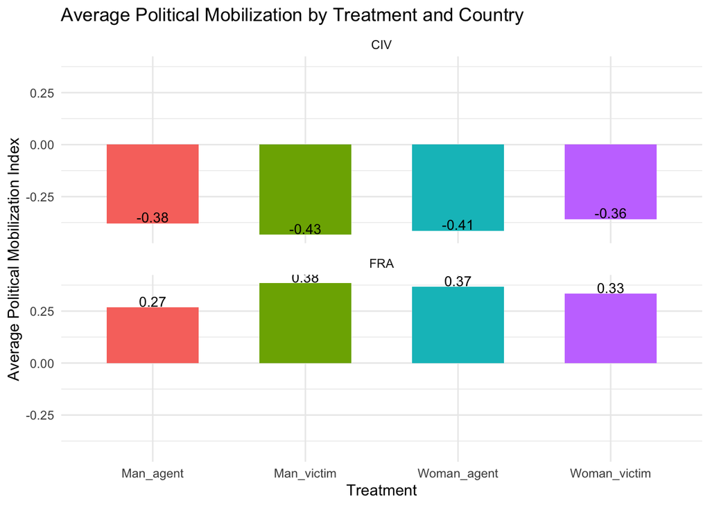

# Secondary hypothesis 2 (S2).

Victimization of climate change communication will differentially increase support for Global South climate financing when the victim is also a woman, among Global North citizens (for all five outcomes). We expect the same among Global South citizens but only for the first four outcomes. For Global South citizens, we expect the last outcome to move in the opposite direction.

|  | Prefers adaptation finance in poor countries vs. France Unadjusted | Prefers adaptation finance in poor countries vs. France Adjusted | Prefers adaptation finance vs. emergency relief Unadjusted | Prefers adaptation finance vs. emergency relief Adjusted | Prefers gender-based adaptation finance vs. general programming Unadjusted | Prefers gender-based adaptation finance vs. general programming Adjusted | Willingness to sign petition Unadjusted | Willingness to sign petition Adjusted | Clicks to learn more about climate adaptation Unadjusted | Clicks to learn more about climate adaptation Adjusted | Willingness to pay Unadjusted | Willingness to pay Adjusted |
| --- | --- | --- | --- | --- | --- | --- | --- | --- | --- | --- | --- | --- |
| (Intercept) | 0.844*** | 0.556* | 0.442*** | 0.447* | 0.340*** | −0.143 | 0.833*** | 0.488* | 0.098*** | 0.058 | 0.826*** | 0.575*** |
|  | (0.018) | (0.238) | (0.024) | (0.219) | (0.023) | (0.270) | (0.018) | (0.199) | (0.014) | (0.088) | (0.018) | (0.120) |
| treatment_female | −0.023 | −0.030 | 0.019 | 0.026 | 0.142*** | 0.154*** | −0.033 | −0.055* | 0.016 | 0.013 | −0.012 | −0.026 |
|  | (0.025) | (0.027) | (0.034) | (0.036) | (0.033) | (0.035) | (0.026) | (0.027) | (0.021) | (0.022) | (0.026) | (0.027) |
| treatment_victim | −0.005 | −0.002 | 0.006 | 0.013 | −0.017 | −0.033 | 0.011 | 0.007 | 0.011 | 0.018 | −0.079** | −0.088** |
|  | (0.025) | (0.027) | (0.034) | (0.037) | (0.032) | (0.034) | (0.025) | (0.026) | (0.021) | (0.023) | (0.028) | (0.028) |
| treatment_female × treatment_victim | 0.016 | 0.030 | −0.046 | −0.063 | −0.011 | −0.013 | 0.007 | 0.026 | −0.011 | −0.013 | 0.071+ | 0.101* |
|  | (0.036) | (0.038) | (0.048) | (0.052) | (0.047) | (0.049) | (0.037) | (0.038) | (0.030) | (0.033) | (0.039) | (0.040) |
| male |  | 0.026 |  | 0.042 |  | −0.059* |  | 0.077*** |  | 0.036* |  | 0.016 |
|  |  | (0.021) |  | (0.029) |  | (0.027) |  | (0.023) |  | (0.018) |  | (0.022) |
| age25-34 years old |  | 0.019 |  | 0.039 |  | 0.007 |  | 0.012 |  | −0.003 |  | 0.038 |
|  |  | (0.028) |  | (0.039) |  | (0.037) |  | (0.029) |  | (0.025) |  | (0.029) |
| age35-44 years old |  | 0.011 |  | 0.062 |  | 0.045 |  | 0.017 |  | 0.047 |  | −0.004 |
|  |  | (0.034) |  | (0.047) |  | (0.045) |  | (0.033) |  | (0.031) |  | (0.035) |
| age45-54 years old |  | −0.006 |  | 0.065 |  | 0.079 |  | 0.033 |  | 0.098* |  | −0.032 |
|  |  | (0.043) |  | (0.060) |  | (0.056) |  | (0.042) |  | (0.045) |  | (0.046) |
| age55-64 years old |  | −0.072 |  | 0.147 |  | −0.080 |  | −0.088 |  | 0.087 |  | −0.049 |
|  |  | (0.100) |  | (0.102) |  | (0.096) |  | (0.093) |  | (0.084) |  | (0.088) |
| age75+ years old |  | 0.552*** |  | −0.620*** |  | 0.312* |  | 0.152+ |  | 0.014 |  | −1.027*** |
|  |  | (0.111) |  | (0.131) |  | (0.134) |  | (0.089) |  | (0.053) |  | (0.065) |
| employmentOther × |  | 0.119 |  | 0.229+ |  | −0.009 |  | −0.007 |  | −0.042 |  | 0.183 |
|  |  | (0.101) |  | (0.137) |  | (0.125) |  | (0.086) |  | (0.100) |  | (0.124) |
| employmentRetired |  | −0.156 |  | 0.123 |  | 0.011 |  | −0.110 |  | −0.015 |  | 0.367** |
|  |  | (0.235) |  | (0.201) |  | (0.207) |  | (0.164) |  | (0.165) |  | (0.117) |
| employmentStudent |  | 0.159+ |  | 0.057 |  | −0.059 |  | −0.158* |  | −0.081 |  | 0.208* |
|  |  | (0.087) |  | (0.104) |  | (0.096) |  | (0.075) |  | (0.069) |  | (0.094) |
| employmentUnemployed and looking for work |  | 0.146+ |  | −0.001 |  | −0.071 |  | −0.073 |  | −0.046 |  | 0.250** |
|  |  | (0.086) |  | (0.103) |  | (0.096) |  | (0.073) |  | (0.068) |  | (0.093) |
| employmentWorking full-time |  | 0.090 |  | 0.091 |  | −0.058 |  | −0.099 |  | −0.074 |  | 0.244** |
|  |  | (0.083) |  | (0.098) |  | (0.091) |  | (0.069) |  | (0.065) |  | (0.090) |

[output cut: 86 more lines]

+ p < 0.1, * p < 0.05, ** p < 0.01, *** p < 0.001  
Note: 6 climate adpatation outcomes. Run on Ivorian sample. Robust SEs.

|  | Prefers adaptation finance in poor countries vs. France Unadjusted | Prefers adaptation finance in poor countries vs. France Adjusted | Prefers adaptation finance vs. emergency relief Unadjusted | Prefers adaptation finance vs. emergency relief Adjusted | Prefers gender-based adaptation finance vs. general programming Unadjusted | Prefers gender-based adaptation finance vs. general programming Adjusted | Willingness to sign petition Unadjusted | Willingness to sign petition Adjusted | Clicks to learn more about climate adaptation Unadjusted | Clicks to learn more about climate adaptation Adjusted | Willingness to pay Unadjusted | Willingness to pay Adjusted |
| --- | --- | --- | --- | --- | --- | --- | --- | --- | --- | --- | --- | --- |
| (Intercept) | 0.473*** | 0.506+ | 0.485*** | 0.403 | 0.270*** | 0.070 | 0.522*** | 0.372 | 0.032*** | −0.131** | 0.491*** | 0.314 |
|  | (0.022) | (0.300) | (0.022) | (0.281) | (0.020) | (0.300) | (0.022) | (0.293) | (0.008) | (0.046) | (0.022) | (0.266) |
| treatment_female | −0.070* | −0.077* | 0.055+ | 0.061+ | 0.082** | 0.090** | −0.022 | −0.008 | 0.011 | 0.008 | 0.029 | 0.034 |
|  | (0.031) | (0.031) | (0.032) | (0.032) | (0.029) | (0.029) | (0.032) | (0.030) | (0.012) | (0.013) | (0.032) | (0.031) |
| treatment_victim | −0.079* | −0.084** | 0.023 | 0.026 | 0.015 | 0.034 | −0.005 | −0.002 | 0.010 | 0.012 | 0.010 | 0.005 |
|  | (0.031) | (0.032) | (0.032) | (0.032) | (0.028) | (0.029) | (0.032) | (0.030) | (0.012) | (0.012) | (0.032) | (0.030) |
| treatment_female × treatment_victim | 0.099* | 0.104* | −0.099* | −0.101* | 0.006 | −0.002 | −0.010 | −0.024 | −0.029+ | −0.026 | −0.040 | −0.037 |
|  | (0.044) | (0.044) | (0.045) | (0.045) | (0.042) | (0.042) | (0.045) | (0.042) | (0.017) | (0.017) | (0.045) | (0.043) |
| male |  | −0.037 |  | 0.029 |  | −0.027 |  | −0.026 |  | 0.002 |  | −0.006 |
|  |  | (0.023) |  | (0.024) |  | (0.022) |  | (0.022) |  | (0.009) |  | (0.023) |
| age25-34 years old |  | −0.102+ |  | 0.132* |  | 0.037 |  | 0.036 |  | −0.003 |  | −0.117* |
|  |  | (0.055) |  | (0.052) |  | (0.053) |  | (0.054) |  | (0.016) |  | (0.054) |
| age35-44 years old |  | −0.108+ |  | 0.170** |  | 0.060 |  | 0.031 |  | −0.001 |  | −0.082 |
|  |  | (0.056) |  | (0.053) |  | (0.054) |  | (0.055) |  | (0.016) |  | (0.054) |
| age45-54 years old |  | −0.156** |  | 0.187*** |  | 0.038 |  | 0.031 |  | 0.021 |  | −0.133* |
|  |  | (0.055) |  | (0.053) |  | (0.053) |  | (0.055) |  | (0.018) |  | (0.054) |
| age55-64 years old |  | −0.105+ |  | 0.242*** |  | 0.010 |  | 0.028 |  | 0.033+ |  | −0.041 |
|  |  | (0.057) |  | (0.054) |  | (0.054) |  | (0.057) |  | (0.020) |  | (0.056) |
| age65-74 years old |  | −0.077 |  | 0.211** |  | 0.002 |  | 0.018 |  | −0.000 |  | 0.019 |
|  |  | (0.074) |  | (0.073) |  | (0.068) |  | (0.070) |  | (0.029) |  | (0.073) |
| age75+ years old |  | 0.034 |  | 0.359*** |  | −0.078 |  | 0.020 |  | −0.019 |  | 0.109 |
|  |  | (0.097) |  | (0.094) |  | (0.083) |  | (0.095) |  | (0.033) |  | (0.095) |
| employmentOther × |  | −0.197+ |  | −0.035 |  | 0.164 |  | −0.017 |  | 0.018 |  | 0.006 |
|  |  | (0.114) |  | (0.127) |  | (0.122) |  | (0.117) |  | (0.048) |  | (0.109) |
| employmentRetired |  | −0.097 |  | −0.095 |  | 0.031 |  | −0.145+ |  | 0.029 |  | −0.033 |
|  |  | (0.081) |  | (0.079) |  | (0.072) |  | (0.075) |  | (0.029) |  | (0.073) |
| employmentStudent |  | −0.094 |  | −0.051 |  | 0.061 |  | −0.151 |  | 0.006 |  | −0.022 |
|  |  | (0.103) |  | (0.102) |  | (0.097) |  | (0.100) |  | (0.029) |  | (0.093) |
| employmentUnemployed and looking for work |  | −0.063 |  | −0.128 |  | −0.006 |  | −0.145+ |  | 0.060+ |  | −0.025 |
|  |  | (0.088) |  | (0.085) |  | (0.079) |  | (0.085) |  | (0.035) |  | (0.080) |

[output cut: 64 more lines]

+ p < 0.1, * p < 0.05, ** p < 0.01, *** p < 0.001  
Note: 6 climate adpatation outcomes. Run on French sample. Robust SEs.

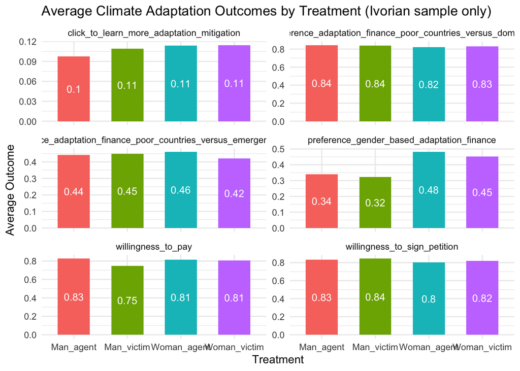

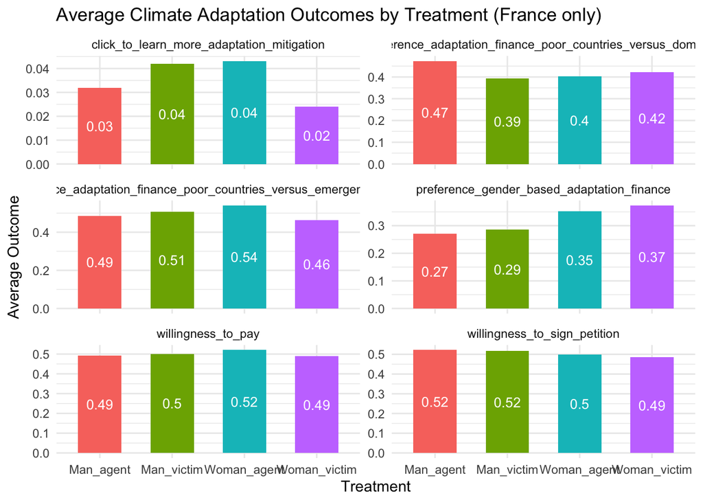

```r
## willingness to pay

library(estimatr)
library(broom)

# make sure Currency_label is a factor with the correct order
df <- df %>%
  mutate(Currency_label = factor(Currency_label,
                                 levels = c("€1","€5","€25","€50","€100",
                                            "500 CFA","2000 CFA","10000 CFA","20000 CFA","40000 CFA")))

# function: run regression for a given treatment var
get_effects <- function(data, sample_label, treat_var, treat_label) {
  data %>%
    group_by(Currency_label) %>%
    do({
      f <- as.formula(paste("willingness_to_pay ~", treat_var))
      mod <- lm_robust(f, data = .)
      tidy(mod, conf.int = TRUE) %>%
        filter(term == treat_var) %>%
        mutate(N = n())
    }) %>%
    ungroup() %>%
    mutate(sample = sample_label,
           treatment = treat_label)
}

# France (euros only)
res_fr_female <- get_effects(df %>% filter(fr_sample == 1 & grepl("€", Currency_label)),
                             "France", "treatment_female", "Female treatment")
res_fr_victim <- get_effects(df %>% filter(fr_sample == 1 & grepl("€", Currency_label)),
                             "France", "treatment_victim", "Victim treatment")

# Côte d’Ivoire (CFA only)
res_cdi_female <- get_effects(df %>% filter(cdi_sample == 1 & grepl("CFA", Currency_label)),
                              "Côte d’Ivoire", "treatment_female", "Female treatment")
res_cdi_victim <- get_effects(df %>% filter(cdi_sample == 1 & grepl("CFA", Currency_label)),
                              "Côte d’Ivoire", "treatment_victim", "Victim treatment")

# Combine all
results <- bind_rows(res_fr_female, res_fr_victim,
                     res_cdi_female, res_cdi_victim)

# Plot
p <- ggplot(results,
       aes(x = Currency_label, y = estimate,
           ymin = conf.low, ymax = conf.high,
           color = treatment, shape = treatment,
           group = treatment)) +
  geom_hline(yintercept = 0, linetype = "dashed") +
  geom_pointrange(position = position_dodge(width = 0.5)) +
  labs(x = "Randomized contribution amount",
       y = "Treatment effect",
       title = "Impact of treatments by contribution amount") +
  facet_wrap(~sample, scales = "free_x", ncol = 2) +
  theme_classic(base_size = 14) +
  theme(axis.text.x = element_text(angle = 45, hjust = 1))


ggsave("treatment_effects_wtp.png", plot = p,
       width = 10, height = 6, dpi = 300)
```

# Exploratory hypotheses.

## Mechanism outcomes

First, in order to probe potential mechanisms underlying our main and secondary hypotheses, we preregister a group of exploratory analyses where we investigate the impact of our treatments (and their interactions) on several psychological and attitudinal outcomes, as well as an open text response on how the treatment made the respondent feel.

|  | Gender paternalism Feminization | Gender paternalism Victimization | Gender paternalism Interaction | Global south paternalism Feminization | Global south paternalism Victimization | Global south paternalism Interaction | People in some parts of the world face more climate consequences Feminization | People in some parts of the world face more climate consequences Victimization | People in some parts of the world face more climate consequences Interaction | Ivory Coast more affected by climate change than France Feminization | Ivory Coast more affected by climate change than France Victimization | Ivory Coast more affected by climate change than France Interaction | Likelihood of climate migration Feminization | Likelihood of climate migration Victimization | Likelihood of climate migration Interaction | Extent to which migration to my country should be decreased Feminization | Extent to which migration to my country should be decreased Victimization | Extent to which migration to my country should be decreased Interaction | Anger/resentment response Feminization | Anger/resentment response Victimization | Anger/resentment response Interaction | Empathetic response Feminization | Empathetic response Victimization | Empathetic response Interaction | Helplessness response Feminization | Helplessness response Victimization | Helplessness response Interaction | Deserving victimhood Feminization | Deserving victimhood Victimization | … |
| --- | --- | --- | --- | --- | --- | --- | --- | --- | --- | --- | --- | --- | --- | --- | --- | --- | --- | --- | --- | --- | --- | --- | --- | --- | --- | --- | --- | --- | --- | --- |
| (Intercept) | 0.751*** | 0.771*** | 0.772*** | 0.822*** | 0.808*** | 0.813*** | 0.577*** | 0.561*** | 0.562*** | 0.681*** | 0.671*** | 0.668*** | 3.761*** | 3.782*** | 3.675*** | 3.311*** | 3.368*** | 3.398*** | 0.074*** | 0.083*** | 0.063*** | 0.790*** | 0.799*** | 0.817*** | 0.137*** | 0.118*** | 0.120*** | 0.615*** | 0.606*** | … |
|  | (0.014) | (0.013) | (0.019) | (0.012) | (0.013) | (0.017) | (0.016) | (0.016) | (0.022) | (0.015) | (0.015) | (0.021) | (0.035) | (0.035) | (0.051) | (0.041) | (0.042) | (0.058) | (0.008) | (0.009) | (0.011) | (0.013) | (0.013) | (0.017) | (0.011) | (0.010) | (0.014) | (0.015) | (0.015) | … |
| treatment_female | 0.022 |  | −0.001 | −0.015 |  | −0.010 | −0.006 |  | −0.002 | 0.001 |  | 0.007 | 0.072 |  | 0.217** | −0.018 |  | −0.060 | 0.026* |  | 0.040* | −0.018 |  | −0.035 | −0.008 |  | −0.005 | −0.031 |  | … |
|  | (0.019) |  | (0.027) | (0.017) |  | (0.025) | (0.022) |  | (0.032) | (0.021) |  | (0.030) | (0.049) |  | (0.069) | (0.059) |  | (0.083) | (0.013) |  | (0.017) | (0.018) |  | (0.025) | (0.015) |  | (0.020) | (0.022) |  | … |
| treatment_victim |  | −0.018 | −0.041 |  | 0.013 | 0.018 |  | 0.026 | 0.030 |  | 0.020 | 0.026 |  | 0.031 | 0.172* |  | −0.131* | −0.174* |  | 0.007 | 0.021 |  | −0.036* | −0.053* |  | 0.029+ | 0.032 |  | −0.013 | … |
|  |  | (0.019) | (0.027) |  | (0.017) | (0.024) |  | (0.022) | (0.031) |  | (0.021) | (0.030) |  | (0.049) | (0.069) |  | (0.059) | (0.082) |  | (0.013) | (0.016) |  | (0.018) | (0.026) |  | (0.015) | (0.022) |  | (0.022) | … |
| treatment_victim × treatment_female |  |  | 0.046 |  |  | −0.010 |  |  | −0.008 |  |  | −0.012 |  |  | −0.287** |  |  | 0.087 |  |  | −0.028 |  |  | 0.034 |  |  | −0.006 |  |  | … |
|  |  |  | (0.038) |  |  | (0.035) |  |  | (0.045) |  |  | (0.042) |  |  | (0.098) |  |  | (0.118) |  |  | (0.025) |  |  | (0.037) |  |  | (0.030) |  |  | … |
| R2 | 0.00 | 0.00 | 0.00 | 0.00 | 0.00 | 0.00 | 0.00 | 0.00 | 0.00 | 0.00 | 0.00 | 0.00 | 0.00 | 0.00 | 0.01 | 0.00 | 0.00 | 0.00 | 0.00 | 0.00 | 0.00 | 0.00 | 0.00 | 0.00 | 0.00 | 0.00 | 0.00 | 0.00 | 0.00 | … |
| Num. obs. | 1981 | 1981 | 1981 | 1975 | 1975 | 1975 | 1973 | 1973 | 1973 | 1969 | 1969 | 1969 | 1965 | 1965 | 1965 | 1963 | 1963 | 1963 | 2021 | 2021 | 2021 | 2021 | 2021 | 2021 | 2021 | 2021 | 2021 | 2021 | 2021 | … |

+ p < 0.1, * p < 0.05, ** p < 0.01, *** p < 0.001  
Note: Mechanism outcomes. Run on French sample. Robust SEs.

|  | Gender paternalism Feminization | Gender paternalism Victimization | Gender paternalism Interaction | Global south paternalism Feminization | Global south paternalism Victimization | Global south paternalism Interaction | People in some parts of the world face more climate consequences Feminization | People in some parts of the world face more climate consequences Victimization | People in some parts of the world face more climate consequences Interaction | Ivory Coast more affected by climate change than France Feminization | Ivory Coast more affected by climate change than France Victimization | Ivory Coast more affected by climate change than France Interaction | Likelihood of climate migration Feminization | Likelihood of climate migration Victimization | Likelihood of climate migration Interaction | Extent to which migration to my country should be decreased Feminization | Extent to which migration to my country should be decreased Victimization | Extent to which migration to my country should be decreased Interaction | Anger/resentment response Feminization | Anger/resentment response Victimization | Anger/resentment response Interaction | Empathetic response Feminization | Empathetic response Victimization | Empathetic response Interaction | Helplessness response Feminization | Helplessness response Victimization | Helplessness response Interaction | Deserving victimhood Feminization | Deserving victimhood Victimization | … |
| --- | --- | --- | --- | --- | --- | --- | --- | --- | --- | --- | --- | --- | --- | --- | --- | --- | --- | --- | --- | --- | --- | --- | --- | --- | --- | --- | --- | --- | --- | --- |
| (Intercept) | 0.896*** | 0.899*** | 0.898*** | 0.917*** | 0.917*** | 0.921*** | 0.581*** | 0.593*** | 0.570*** | 0.783*** | 0.772*** | 0.786*** | 3.521*** | 3.488*** | 3.474*** | 2.877*** | 2.931*** | 2.856*** | 0.042*** | 0.052*** | 0.053*** | 0.919*** | 0.891*** | 0.895*** | 0.039*** | 0.057*** | 0.051*** | 0.901*** | 0.894*** | … |
|  | (0.010) | (0.010) | (0.015) | (0.009) | (0.009) | (0.013) | (0.017) | (0.017) | (0.024) | (0.014) | (0.014) | (0.020) | (0.044) | (0.044) | (0.064) | (0.046) | (0.046) | (0.065) | (0.007) | (0.008) | (0.011) | (0.009) | (0.011) | (0.015) | (0.007) | (0.008) | (0.011) | (0.010) | (0.010) | … |
| treatment_female | 0.011 |  | 0.002 | 0.008 |  | −0.007 | 0.033 |  | 0.047 | −0.007 |  | −0.028 | 0.005 |  | 0.028 | 0.112+ |  | 0.151+ | 0.008 |  | −0.002 | −0.017 |  | −0.009 | 0.009 |  | 0.012 | 0.015 |  | … |
|  | (0.014) |  | (0.021) | (0.013) |  | (0.019) | (0.024) |  | (0.034) | (0.020) |  | (0.029) | (0.062) |  | (0.088) | (0.065) |  | (0.092) | (0.010) |  | (0.015) | (0.014) |  | (0.021) | (0.010) |  | (0.016) | (0.014) |  | … |
| treatment_victim |  | 0.005 | −0.004 |  | 0.006 | −0.009 |  | 0.009 | 0.023 |  | 0.015 | −0.006 |  | 0.070 | 0.094 |  | 0.003 | 0.042 |  | −0.012 | −0.023+ |  | 0.040** | 0.048* |  | −0.028** | −0.025+ |  | 0.029* | … |
|  |  | (0.014) | (0.021) |  | (0.013) | (0.019) |  | (0.024) | (0.034) |  | (0.020) | (0.028) |  | (0.062) | (0.089) |  | (0.065) | (0.092) |  | (0.010) | (0.014) |  | (0.014) | (0.019) |  | (0.010) | (0.013) |  | (0.014) | … |
| treatment_victim × treatment_female |  |  | 0.018 |  |  | 0.029 |  |  | −0.027 |  |  | 0.043 |  |  | −0.048 |  |  | −0.080 |  |  | 0.021 |  |  | −0.016 |  |  | −0.005 |  |  | … |
|  |  |  | (0.029) |  |  | (0.026) |  |  | (0.047) |  |  | (0.040) |  |  | (0.124) |  |  | (0.130) |  |  | (0.020) |  |  | (0.028) |  |  | (0.020) |  |  | … |
| R2 | 0.00 | 0.00 | 0.00 | 0.00 | 0.00 | 0.00 | 0.00 | 0.00 | 0.00 | 0.00 | 0.00 | 0.00 | 0.00 | 0.00 | 0.00 | 0.00 | 0.00 | 0.00 | 0.00 | 0.00 | 0.00 | 0.00 | 0.00 | 0.01 | 0.00 | 0.00 | 0.01 | 0.00 | 0.00 | … |
| Num. obs. | 1710 | 1710 | 1710 | 1710 | 1710 | 1710 | 1710 | 1710 | 1710 | 1710 | 1710 | 1710 | 1710 | 1710 | 1710 | 1710 | 1710 | 1710 | 1710 | 1710 | 1710 | 1710 | 1710 | 1710 | 1710 | 1710 | 1710 | 1710 | 1710 | … |

+ p < 0.1, * p < 0.05, ** p < 0.01, *** p < 0.001  
Note: Mechanism outcomes. Run on Ivorian sample. Robust SEs.

## Heterogeneous treatment effects

Second, we probe heterogeneity of treatment effects by conducting subgroup analysis and interaction analyses (between treatment and covariates of interest) with the following covariates: gender, baseline climate beliefs, age, whether or not has children, socioeconomic status, and ambivalent sexism.

### Gender

|  | Political mobilization index | Preference: poor countries vs. France | Preference: adaptation vs. emergency relief | Preference: gender-based vs. general | Willingness to sign petition | Clicks: adaptation and mitigation | Willingness to pay |
| --- | --- | --- | --- | --- | --- | --- | --- |
| (Intercept) | -0.391*** | 0.833*** | 0.417*** | 0.384*** | 0.804*** | 0.071*** | 0.780*** |
|  | (0.075) | (0.020) | (0.027) | (0.027) | (0.022) | (0.014) | (0.023) |
| treatment_female | 0.105 | -0.013 | -0.009 | 0.129*** | -0.017 | 0.005 | 0.027 |
|  | (0.104) | (0.029) | (0.038) | (0.038) | (0.031) | (0.020) | (0.031) |
| male | -0.027 | 0.013 | 0.052 | -0.086* | 0.058* | 0.055** | 0.021 |
|  | (0.098) | (0.026) | (0.035) | (0.033) | (0.027) | (0.020) | (0.029) |
| treatment_female × male | -0.138 | -0.003 | 0.004 | 0.008 | -0.016 | 0.006 | -0.011 |
|  | (0.137) | (0.037) | (0.049) | (0.048) | (0.038) | (0.029) | (0.040) |
| R2 | 0.00 | 0.00 | 0.00 | 0.03 | 0.01 | 0.01 | 0.00 |
| Num. obs. | 1694 | 1694 | 1694 | 1694 | 1694 | 1694 | 1694 |
| (Intercept) | 0.290*** | 0.453*** | 0.467*** | 0.294*** | 0.540*** | 0.037*** | 0.494*** |
|  | (0.060) | (0.023) | (0.023) | (0.021) | (0.023) | (0.009) | (0.023) |
| treatment_female | 0.016 | -0.004 | 0.007 | 0.086** | -0.036 | -0.005 | -0.004 |
|  | (0.085) | (0.032) | (0.032) | (0.030) | (0.032) | (0.012) | (0.032) |
| male | 0.070 | -0.038 | 0.057+ | -0.032 | -0.040 | 0.001 | 0.004 |
|  | (0.089) | (0.031) | (0.032) | (0.028) | (0.032) | (0.012) | (0.032) |
| treatment_female × male | 0.020 | -0.037 | -0.002 | -0.004 | 0.017 | 0.003 | 0.027 |
|  | (0.126) | (0.044) | (0.045) | (0.042) | (0.045) | (0.017) | (0.045) |
| R2 | 0.00 | 0.00 | 0.00 | 0.01 | 0.00 | 0.00 | 0.00 |
| Num. obs. | 2003 | 1990 | 1991 | 1993 | 1993 | 1986 | 1993 |

+ p < 0.1, * p < 0.05, ** p < 0.01, *** p < 0.001  
Note: Robust SEs.

|  | Political mobilization index | Preference: poor countries vs. France | Preference: adaptation vs. emergency relief | Preference: gender-based vs. general | Willingness to sign petition | Clicks: adaptation and mitigation | Willingness to pay |
| --- | --- | --- | --- | --- | --- | --- | --- |
| (Intercept) | -0.348*** | 0.838*** | 0.434*** | 0.448*** | 0.779*** | 0.065*** | 0.826*** |
|  | (0.073) | (0.020) | (0.027) | (0.027) | (0.023) | (0.013) | (0.021) |
| treatment_victim | 0.020 | -0.022 | -0.043 | 0.003 | 0.032 | 0.018 | -0.064* |
|  | (0.104) | (0.029) | (0.038) | (0.038) | (0.031) | (0.020) | (0.031) |
| male | -0.084 | -0.008 | 0.030 | -0.063+ | 0.065* | 0.068*** | -0.002 |
|  | (0.097) | (0.026) | (0.035) | (0.035) | (0.028) | (0.020) | (0.027) |
| treatment_victim × male | -0.027 | 0.039 | 0.047 | -0.042 | -0.028 | -0.020 | 0.033 |
|  | (0.137) | (0.037) | (0.049) | (0.049) | (0.038) | (0.029) | (0.040) |
| R2 | 0.00 | 0.00 | 0.00 | 0.01 | 0.00 | 0.01 | 0.00 |
| Num. obs. | 1694 | 1694 | 1694 | 1694 | 1694 | 1694 | 1694 |
| (Intercept) | 0.295*** | 0.460*** | 0.469*** | 0.323*** | 0.491*** | 0.040*** | 0.484*** |
|  | (0.059) | (0.023) | (0.023) | (0.021) | (0.023) | (0.009) | (0.023) |
| treatment_victim | 0.006 | -0.018 | 0.004 | 0.028 | 0.060+ | -0.010 | 0.015 |
|  | (0.084) | (0.032) | (0.032) | (0.030) | (0.032) | (0.012) | (0.032) |
| male | 0.042 | -0.044 | 0.083** | -0.026 | 0.041 | -0.004 | 0.042 |
|  | (0.087) | (0.032) | (0.032) | (0.029) | (0.032) | (0.012) | (0.032) |
| treatment_victim × male | 0.077 | -0.026 | -0.056 | -0.018 | -0.142** | 0.012 | -0.049 |
|  | (0.126) | (0.044) | (0.045) | (0.042) | (0.045) | (0.017) | (0.045) |
| R2 | 0.00 | 0.00 | 0.00 | 0.00 | 0.01 | 0.00 | 0.00 |
| Num. obs. | 2003 | 1990 | 1991 | 1993 | 1993 | 1986 | 1993 |

+ p < 0.1, * p < 0.05, ** p < 0.01, *** p < 0.001  
Note: Robust SEs.

### Baseline climate beliefs

For the HTEs, we operationalize this as $climate\_beliefs\_binary = 1$ if the respondent says “Moderately”, “A lot”, or “A great deal” to the following question. Other responses are coded as 0. - To what extent do you think climate change already affects or will affect your personal life negatively? Some ways climate change could affect you include irregular rains, more frequent floods, and worsening harvests that make life more expensive and more difficult.

|  | Political mobilization index | Preference: poor countries vs. France | Preference: adaptation vs. emergency relief | Preference: gender-based vs. general | Willingness to sign petition | Clicks: adaptation and mitigation | Willingness to pay |
| --- | --- | --- | --- | --- | --- | --- | --- |
| (Intercept) | 0.005 | 0.850*** | 0.352*** | 0.432*** | 0.845*** | 0.075*** | 0.779*** |
|  | (0.106) | (0.025) | (0.033) | (0.034) | (0.025) | (0.018) | (0.028) |
| treatment_female | -0.068 | -0.060 | 0.084+ | 0.132** | -0.086* | -0.003 | -0.005 |
|  | (0.153) | (0.038) | (0.048) | (0.049) | (0.040) | (0.026) | (0.041) |
| climate_beliefs_binary | -0.547*** | -0.011 | 0.124** | -0.135*** | -0.009 | 0.038+ | 0.009 |
|  | (0.118) | (0.029) | (0.038) | (0.039) | (0.029) | (0.022) | (0.033) |
| treatment_female × climate_beliefs_binary | 0.130 | 0.058 | -0.118* | 0.009 | 0.074+ | 0.017 | 0.037 |
|  | (0.169) | (0.043) | (0.056) | (0.056) | (0.045) | (0.032) | (0.047) |
| R2 | 0.02 | 0.00 | 0.01 | 0.03 | 0.00 | 0.00 | 0.00 |
| Num. obs. | 1710 | 1710 | 1710 | 1710 | 1710 | 1710 | 1710 |
| (Intercept) | 1.108*** | 0.377*** | 0.514*** | 0.251*** | 0.366*** | 0.022* | 0.328*** |
|  | (0.103) | (0.036) | (0.037) | (0.032) | (0.036) | (0.011) | (0.035) |
| treatment_female | -0.072 | -0.015 | -0.001 | 0.094* | 0.006 | 0.003 | 0.052 |
|  | (0.138) | (0.050) | (0.051) | (0.047) | (0.050) | (0.016) | (0.049) |
| climate_beliefs_binary | -0.956*** | 0.069+ | -0.021 | 0.032 | 0.188*** | 0.019 | 0.206*** |
|  | (0.114) | (0.040) | (0.041) | (0.036) | (0.040) | (0.013) | (0.039) |
| treatment_female × climate_beliefs_binary | 0.096 | -0.005 | 0.007 | -0.010 | -0.037 | -0.008 | -0.049 |
|  | (0.154) | (0.055) | (0.057) | (0.052) | (0.055) | (0.018) | (0.055) |
| R2 | 0.06 | 0.00 | 0.00 | 0.01 | 0.02 | 0.00 | 0.02 |
| Num. obs. | 2004 | 1991 | 1992 | 1994 | 1994 | 1987 | 1994 |

+ p < 0.1, * p < 0.05, ** p < 0.01, *** p < 0.001  
Note: Robust SEs.

|  | Political mobilization index | Preference: poor countries vs. France | Preference: adaptation vs. emergency relief | Preference: gender-based vs. general | Willingness to sign petition | Clicks: adaptation and mitigation | Willingness to pay |
| --- | --- | --- | --- | --- | --- | --- | --- |
| (Intercept) | -0.100 | 0.835*** | 0.376*** | 0.500*** | 0.825*** | 0.057*** | 0.804*** |
|  | (0.113) | (0.027) | (0.035) | (0.036) | (0.027) | (0.017) | (0.029) |
| treatment_victim | 0.138 | -0.027 | 0.030 | -0.009 | -0.040 | 0.032 | -0.052 |
|  | (0.153) | (0.038) | (0.048) | (0.050) | (0.039) | (0.026) | (0.041) |
| climate_beliefs_binary | -0.382** | -0.003 | 0.097* | -0.116** | -0.011 | 0.063** | 0.020 |
|  | (0.124) | (0.030) | (0.040) | (0.041) | (0.031) | (0.021) | (0.032) |
| treatment_victim × climate_beliefs_binary | -0.197 | 0.039 | -0.060 | -0.021 | 0.072 | -0.033 | 0.012 |
|  | (0.170) | (0.043) | (0.056) | (0.056) | (0.044) | (0.031) | (0.047) |
| R2 | 0.02 | 0.00 | 0.00 | 0.01 | 0.00 | 0.00 | 0.00 |
| Num. obs. | 1710 | 1710 | 1710 | 1710 | 1710 | 1710 | 1710 |
| (Intercept) | 1.004*** | 0.373*** | 0.471*** | 0.275*** | 0.353*** | 0.039** | 0.358*** |
|  | (0.092) | (0.034) | (0.035) | (0.031) | (0.034) | (0.014) | (0.034) |
| treatment_victim | 0.143 | -0.007 | 0.091+ | 0.055 | 0.035 | -0.034* | -0.006 |
|  | (0.138) | (0.050) | (0.051) | (0.047) | (0.050) | (0.015) | (0.049) |
| climate_beliefs_binary | -0.867*** | 0.083* | 0.052 | 0.045 | 0.199*** | -0.002 | 0.186*** |
|  | (0.104) | (0.038) | (0.039) | (0.035) | (0.038) | (0.015) | (0.038) |
| treatment_victim × climate_beliefs_binary | -0.090 | -0.030 | -0.144* | -0.046 | -0.061 | 0.036* | -0.011 |
|  | (0.154) | (0.055) | (0.057) | (0.053) | (0.056) | (0.018) | (0.055) |
| R2 | 0.06 | 0.00 | 0.00 | 0.00 | 0.02 | 0.00 | 0.02 |
| Num. obs. | 2004 | 1991 | 1992 | 1994 | 1994 | 1987 | 1994 |

+ p < 0.1, * p < 0.05, ** p < 0.01, *** p < 0.001  
Note: Robust SEs.

### Age

For the HTEs, we operationalize this as $above\_median\_age = 1$ if the respondent’s age is above the median age category. Other responses are coded as 0.

|  | Political mobilization index | Preference: poor countries vs. France | Preference: adaptation vs. emergency relief | Preference: gender-based vs. general | Willingness to sign petition | Clicks: adaptation and mitigation | Willingness to pay |
| --- | --- | --- | --- | --- | --- | --- | --- |
| (Intercept) | -0.392*** | 0.842*** | 0.428*** | 0.333*** | 0.836*** | 0.095*** | 0.786*** |
|  | (0.050) | (0.013) | (0.018) | (0.017) | (0.013) | (0.011) | (0.015) |
| treatment_female | 0.069 | -0.014 | 0.007 | 0.125*** | -0.037+ | 0.005 | 0.024 |
|  | (0.071) | (0.019) | (0.025) | (0.025) | (0.020) | (0.015) | (0.020) |
| above_median_age | -0.139 | -0.005 | 0.165** | -0.019 | 0.025 | 0.079+ | 0.005 |
|  | (0.167) | (0.042) | (0.056) | (0.053) | (0.040) | (0.043) | (0.047) |
| treatment_female × above_median_age | -0.469* | -0.015 | -0.117 | 0.112 | 0.075 | 0.057 | -0.006 |
|  | (0.217) | (0.061) | (0.079) | (0.077) | (0.053) | (0.063) | (0.064) |
| R2 | 0.01 | 0.00 | 0.01 | 0.02 | 0.00 | 0.01 | 0.00 |
| Num. obs. | 1710 | 1710 | 1710 | 1710 | 1710 | 1710 | 1710 |
| (Intercept) | 0.246*** | 0.483*** | 0.485*** | 0.324*** | 0.596*** | 0.027*** | 0.543*** |
|  | (0.065) | (0.024) | (0.024) | (0.022) | (0.023) | (0.008) | (0.024) |
| treatment_female | -0.060 | -0.002 | -0.051 | 0.059+ | -0.062+ | -0.006 | 0.010 |
|  | (0.094) | (0.034) | (0.034) | (0.032) | (0.034) | (0.010) | (0.034) |
| above_median_age | 0.143 | -0.088** | 0.020 | -0.082** | -0.137*** | 0.018 | -0.084** |
|  | (0.089) | (0.032) | (0.032) | (0.029) | (0.031) | (0.012) | (0.032) |
| treatment_female × above_median_age | 0.144 | -0.031 | 0.098* | 0.047 | 0.064 | 0.004 | 0.000 |
|  | (0.126) | (0.045) | (0.045) | (0.042) | (0.045) | (0.016) | (0.045) |
| R2 | 0.01 | 0.01 | 0.01 | 0.01 | 0.01 | 0.00 | 0.01 |
| Num. obs. | 2004 | 1991 | 1992 | 1994 | 1994 | 1987 | 1994 |

+ p < 0.1, * p < 0.05, ** p < 0.01, *** p < 0.001  
Note: Robust SEs.

|  | Political mobilization index | Preference: poor countries vs. France | Preference: adaptation vs. emergency relief | Preference: gender-based vs. general | Willingness to sign petition | Clicks: adaptation and mitigation | Willingness to pay |
| --- | --- | --- | --- | --- | --- | --- | --- |
| (Intercept) | -0.367*** | 0.835*** | 0.438*** | 0.405*** | 0.812*** | 0.092*** | 0.819*** |
|  | (0.050) | (0.013) | (0.018) | (0.018) | (0.014) | (0.010) | (0.014) |
| treatment_victim | 0.019 | 0.001 | -0.013 | -0.020 | 0.011 | 0.011 | -0.043* |
|  | (0.071) | (0.019) | (0.025) | (0.025) | (0.020) | (0.015) | (0.021) |
| above_median_age | -0.316+ | -0.022 | 0.137* | 0.057 | 0.051 | 0.145** | 0.006 |
|  | (0.167) | (0.046) | (0.058) | (0.059) | (0.041) | (0.049) | (0.045) |
| treatment_victim × above_median_age | -0.115 | 0.018 | -0.056 | -0.032 | 0.021 | -0.070 | -0.003 |
|  | (0.220) | (0.061) | (0.080) | (0.080) | (0.054) | (0.064) | (0.064) |
| R2 | 0.01 | 0.00 | 0.00 | 0.00 | 0.00 | 0.01 | 0.00 |
| Num. obs. | 1710 | 1710 | 1710 | 1710 | 1710 | 1710 | 1710 |
| (Intercept) | 0.243*** | 0.516*** | 0.461*** | 0.345*** | 0.569*** | 0.030*** | 0.547*** |
|  | (0.062) | (0.024) | (0.024) | (0.023) | (0.024) | (0.008) | (0.024) |
| treatment_victim | -0.054 | -0.069* | -0.002 | 0.014 | -0.007 | -0.011 | 0.002 |
|  | (0.094) | (0.034) | (0.034) | (0.032) | (0.034) | (0.010) | (0.034) |
| above_median_age | 0.132 | -0.140*** | 0.091** | -0.063* | -0.105*** | 0.014 | -0.074* |
|  | (0.086) | (0.032) | (0.032) | (0.030) | (0.032) | (0.012) | (0.032) |
| treatment_victim × above_median_age | 0.163 | 0.072 | -0.044 | 0.010 | -0.001 | 0.011 | -0.019 |
|  | (0.126) | (0.045) | (0.045) | (0.042) | (0.045) | (0.016) | (0.045) |
| R2 | 0.01 | 0.01 | 0.01 | 0.00 | 0.01 | 0.00 | 0.01 |
| Num. obs. | 2004 | 1991 | 1992 | 1994 | 1994 | 1987 | 1994 |

+ p < 0.1, * p < 0.05, ** p < 0.01, *** p < 0.001  
Note: Robust SEs.

### Has children

|  | Political mobilization index | Preference: poor countries vs. France | Preference: adaptation vs. emergency relief | Preference: gender-based vs. general | Willingness to sign petition | Clicks: adaptation and mitigation | Willingness to pay |
| --- | --- | --- | --- | --- | --- | --- | --- |
| (Intercept) | -0.103 | 0.844*** | 0.385*** | 0.269*** | 0.806*** | 0.094*** | 0.728*** |
|  | (0.065) | (0.017) | (0.023) | (0.021) | (0.019) | (0.014) | (0.021) |
| treatment_female | -0.022 | -0.033 | 0.037 | 0.126*** | -0.081** | 0.014 | 0.041 |
|  | (0.091) | (0.025) | (0.033) | (0.031) | (0.028) | (0.020) | (0.029) |
| has_children | -0.641*** | -0.005 | 0.126*** | 0.130*** | 0.067** | 0.021 | 0.123*** |
|  | (0.093) | (0.025) | (0.034) | (0.032) | (0.025) | (0.021) | (0.028) |
| treatment_female × has_children | 0.084 | 0.038 | -0.086+ | 0.023 | 0.111** | -0.007 | -0.036 |
|  | (0.131) | (0.036) | (0.048) | (0.047) | (0.036) | (0.030) | (0.038) |
| R2 | 0.05 | 0.00 | 0.01 | 0.04 | 0.03 | 0.00 | 0.02 |
| Num. obs. | 1710 | 1710 | 1710 | 1710 | 1710 | 1710 | 1710 |
| (Intercept) | 0.390*** | 0.441*** | 0.524*** | 0.265*** | 0.497*** | 0.032*** | 0.465*** |
|  | (0.076) | (0.027) | (0.027) | (0.024) | (0.027) | (0.010) | (0.027) |
| treatment_female | 0.051 | 0.017 | -0.051 | 0.088* | -0.039 | -0.008 | 0.012 |
|  | (0.109) | (0.039) | (0.039) | (0.036) | (0.039) | (0.013) | (0.039) |
| has_children | -0.097 | -0.012 | -0.041 | 0.020 | 0.034 | 0.007 | 0.047 |
|  | (0.094) | (0.033) | (0.033) | (0.030) | (0.033) | (0.012) | (0.033) |
| treatment_female × has_children | -0.038 | -0.055 | 0.084+ | -0.005 | 0.017 | 0.006 | -0.005 |
|  | (0.134) | (0.047) | (0.048) | (0.044) | (0.048) | (0.017) | (0.048) |
| R2 | 0.00 | 0.00 | 0.00 | 0.01 | 0.00 | 0.00 | 0.00 |
| Num. obs. | 2004 | 1991 | 1992 | 1994 | 1994 | 1987 | 1994 |

+ p < 0.1, * p < 0.05, ** p < 0.01, *** p < 0.001  
Note: Robust SEs.

|  | Political mobilization index | Preference: poor countries vs. France | Preference: adaptation vs. emergency relief | Preference: gender-based vs. general | Willingness to sign petition | Clicks: adaptation and mitigation | Willingness to pay |
| --- | --- | --- | --- | --- | --- | --- | --- |
| (Intercept) | -0.084 | 0.832*** | 0.410*** | 0.339*** | 0.769*** | 0.108*** | 0.788*** |
|  | (0.064) | (0.017) | (0.023) | (0.022) | (0.020) | (0.014) | (0.019) |
| treatment_victim | -0.061 | -0.008 | -0.014 | -0.013 | -0.007 | -0.015 | -0.081** |
|  | (0.091) | (0.025) | (0.033) | (0.031) | (0.028) | (0.020) | (0.029) |
| has_children | -0.677*** | 0.002 | 0.088** | 0.155*** | 0.103*** | -0.005 | 0.068** |
|  | (0.093) | (0.026) | (0.034) | (0.033) | (0.026) | (0.021) | (0.026) |
| treatment_victim × has_children | 0.157 | 0.023 | -0.011 | -0.026 | 0.040 | 0.044 | 0.075* |
|  | (0.131) | (0.036) | (0.048) | (0.047) | (0.036) | (0.030) | (0.038) |
| R2 | 0.05 | 0.00 | 0.01 | 0.02 | 0.03 | 0.00 | 0.02 |
| Num. obs. | 1710 | 1710 | 1710 | 1710 | 1710 | 1710 | 1710 |
| (Intercept) | 0.411*** | 0.454*** | 0.491*** | 0.319*** | 0.466*** | 0.031** | 0.454*** |
|  | (0.076) | (0.028) | (0.028) | (0.026) | (0.028) | (0.010) | (0.028) |
| treatment_victim | 0.009 | -0.009 | 0.015 | -0.022 | 0.023 | -0.004 | 0.033 |
|  | (0.109) | (0.039) | (0.039) | (0.036) | (0.039) | (0.013) | (0.039) |
| has_children | -0.140 | -0.023 | 0.032 | -0.013 | 0.067* | 0.010 | 0.077* |
|  | (0.092) | (0.034) | (0.034) | (0.031) | (0.034) | (0.012) | (0.034) |
| treatment_victim × has_children | 0.049 | -0.032 | -0.062 | 0.062 | -0.050 | -0.001 | -0.064 |
|  | (0.134) | (0.047) | (0.048) | (0.044) | (0.048) | (0.017) | (0.048) |
| R2 | 0.00 | 0.00 | 0.00 | 0.00 | 0.00 | 0.00 | 0.00 |
| Num. obs. | 2004 | 1991 | 1992 | 1994 | 1994 | 1987 | 1994 |

+ p < 0.1, * p < 0.05, ** p < 0.01, *** p < 0.001  
Note: Robust SEs.

### Socioeconomic status

For the HTEs, we operationalize this as $above\_median\_edu = 1$ if the respondent’s education is above the median level, 0 otherwise.

```
##
##                                                         0    1
##   Informal education only (including Koranic school)   43    0
##   No formal education                                  54    0
##   Post-university                                       0  222
##   Primary school                                       75    0
##   Secondary school                                   1274    0
##   University                                         2063    0
```

|  | Political mobilization index | Preference: poor countries vs. France | Preference: adaptation vs. emergency relief | Preference: gender-based vs. general | Willingness to sign petition | Clicks: adaptation and mitigation | Willingness to pay |
| --- | --- | --- | --- | --- | --- | --- | --- |
| (Intercept) | -0.402*** | 0.839*** | 0.446*** | 0.326*** | 0.837*** | 0.101*** | 0.791*** |
|  | (0.049) | (0.013) | (0.017) | (0.016) | (0.013) | (0.011) | (0.014) |
| treatment_female | 0.033 | -0.010 | -0.015 | 0.147*** | -0.032+ | 0.012 | 0.018 |
|  | (0.069) | (0.018) | (0.025) | (0.024) | (0.019) | (0.015) | (0.020) |
| above_median_edu | -0.074 | 0.044 | -0.028 | 0.092 | 0.024 | 0.038 | -0.093 |
|  | (0.205) | (0.051) | (0.078) | (0.078) | (0.055) | (0.055) | (0.072) |
| treatment_female × above_median_edu | -0.259 | -0.101 | 0.210+ | -0.202+ | 0.058 | -0.015 | 0.102 |
|  | (0.306) | (0.083) | (0.109) | (0.108) | (0.075) | (0.076) | (0.094) |
| R2 | 0.00 | 0.00 | 0.00 | 0.02 | 0.00 | 0.00 | 0.00 |
| Num. obs. | 1710 | 1710 | 1710 | 1710 | 1710 | 1710 | 1710 |
| (Intercept) | 0.347*** | 0.429*** | 0.488*** | 0.277*** | 0.511*** | 0.035*** | 0.484*** |
|  | (0.046) | (0.016) | (0.016) | (0.015) | (0.016) | (0.006) | (0.016) |
| treatment_female | 0.019 | -0.014 | 0.003 | 0.084*** | -0.019 | -0.002 | 0.018 |
|  | (0.065) | (0.023) | (0.023) | (0.022) | (0.023) | (0.008) | (0.023) |
| above_median_edu | -0.318+ | 0.063 | 0.124* | 0.006 | 0.121* | 0.024 | 0.172** |
|  | (0.185) | (0.064) | (0.062) | (0.057) | (0.061) | (0.030) | (0.061) |
| treatment_female × above_median_edu | 0.075 | -0.090 | 0.027 | 0.005 | -0.121 | -0.028 | -0.138 |
|  | (0.266) | (0.089) | (0.087) | (0.084) | (0.088) | (0.037) | (0.088) |
| R2 | 0.00 | 0.00 | 0.00 | 0.01 | 0.00 | 0.00 | 0.00 |
| Num. obs. | 2004 | 1991 | 1992 | 1994 | 1994 | 1987 | 1994 |

+ p < 0.1, * p < 0.05, ** p < 0.01, *** p < 0.001  
Note: Robust SEs.

|  | Political mobilization index | Preference: poor countries vs. France | Preference: adaptation vs. emergency relief | Preference: gender-based vs. general | Willingness to sign petition | Clicks: adaptation and mitigation | Willingness to pay |
| --- | --- | --- | --- | --- | --- | --- | --- |
| (Intercept) | -0.383*** | 0.829*** | 0.447*** | 0.413*** | 0.812*** | 0.105*** | 0.819*** |
|  | (0.049) | (0.013) | (0.017) | (0.017) | (0.014) | (0.011) | (0.014) |
| treatment_victim | -0.004 | 0.011 | -0.017 | -0.025 | 0.018 | 0.005 | -0.037+ |
|  | (0.069) | (0.018) | (0.025) | (0.024) | (0.019) | (0.015) | (0.020) |
| above_median_edu | -0.229 | 0.067 | 0.074 | -0.038 | 0.084+ | 0.020 | 0.014 |
|  | (0.200) | (0.046) | (0.075) | (0.073) | (0.047) | (0.049) | (0.056) |
| treatment_victim × above_median_edu | 0.052 | -0.163+ | 0.009 | 0.061 | -0.068 | 0.024 | -0.129 |
|  | (0.312) | (0.086) | (0.112) | (0.109) | (0.076) | (0.077) | (0.096) |
| R2 | 0.00 | 0.00 | 0.00 | 0.00 | 0.00 | 0.00 | 0.00 |
| Num. obs. | 1710 | 1710 | 1710 | 1710 | 1710 | 1710 | 1710 |
| (Intercept) | 0.342*** | 0.434*** | 0.501*** | 0.305*** | 0.503*** | 0.036*** | 0.498*** |
|  | (0.045) | (0.016) | (0.017) | (0.015) | (0.017) | (0.006) | (0.017) |
| treatment_victim | 0.029 | -0.024 | -0.022 | 0.028 | -0.002 | -0.003 | -0.009 |
|  | (0.065) | (0.023) | (0.023) | (0.022) | (0.023) | (0.008) | (0.023) |
| above_median_edu | -0.320* | 0.053 | 0.140* | 0.067 | 0.105+ | 0.015 | 0.091 |
|  | (0.158) | (0.059) | (0.057) | (0.057) | (0.058) | (0.026) | (0.058) |
| treatment_victim × above_median_edu | 0.101 | -0.089 | -0.012 | -0.132 | -0.106 | -0.012 | 0.027 |
|  | (0.280) | (0.090) | (0.089) | (0.084) | (0.090) | (0.036) | (0.090) |
| R2 | 0.00 | 0.00 | 0.01 | 0.00 | 0.00 | 0.00 | 0.00 |
| Num. obs. | 2004 | 1991 | 1992 | 1994 | 1994 | 1987 | 1994 |

+ p < 0.1, * p < 0.05, ** p < 0.01, *** p < 0.001  
Note: Robust SEs.

### Ambivalent sexism

For the HTEs, we use the $ambivalent\_sexism\_index$.

|  | Political mobilization index | Preference: poor countries vs. France | Preference: adaptation vs. emergency relief | Preference: gender-based vs. general | Willingness to sign petition | Clicks: adaptation and mitigation | Willingness to pay |
| --- | --- | --- | --- | --- | --- | --- | --- |
| (Intercept) | 1.162*** | 0.491*** | 0.787*** | 0.298** | 0.787*** | -0.015 | 0.591*** |
|  | (0.289) | (0.080) | (0.097) | (0.094) | (0.068) | (0.056) | (0.078) |
| treatment_female | 0.181 | 0.076 | -0.370** | -0.026 | -0.106 | 0.073 | 0.224* |
|  | (0.399) | (0.111) | (0.133) | (0.133) | (0.104) | (0.078) | (0.104) |
| ambivalent_sexism_index | -0.434*** | 0.097*** | -0.095*** | 0.009 | 0.014 | 0.033* | 0.054** |
|  | (0.079) | (0.021) | (0.026) | (0.026) | (0.018) | (0.016) | (0.021) |
| treatment_female × ambivalent_sexism_index | -0.042 | -0.026 | 0.101** | 0.045 | 0.021 | -0.017 | -0.055* |
|  | (0.108) | (0.029) | (0.036) | (0.036) | (0.028) | (0.022) | (0.028) |
| R2 | 0.05 | 0.02 | 0.01 | 0.02 | 0.00 | 0.00 | 0.00 |
| Num. obs. | 1710 | 1710 | 1710 | 1710 | 1710 | 1710 | 1710 |
| (Intercept) | 1.462*** | 0.345*** | 0.664*** | 0.019 | 0.225** | 0.038 | 0.308*** |
|  | (0.252) | (0.086) | (0.085) | (0.075) | (0.086) | (0.035) | (0.085) |
| treatment_female | 0.067 | 0.019 | -0.003 | -0.087 | 0.058 | -0.036 | 0.096 |
|  | (0.370) | (0.122) | (0.122) | (0.111) | (0.122) | (0.048) | (0.121) |
| ambivalent_sexism_index | -0.339*** | 0.026 | -0.050* | 0.077*** | 0.088*** | -0.000 | 0.056* |
|  | (0.075) | (0.025) | (0.025) | (0.023) | (0.025) | (0.010) | (0.025) |
| treatment_female × ambivalent_sexism_index | -0.013 | -0.012 | 0.002 | 0.052 | -0.025 | 0.010 | -0.026 |
|  | (0.110) | (0.036) | (0.036) | (0.033) | (0.036) | (0.014) | (0.036) |
| R2 | 0.02 | 0.00 | 0.00 | 0.03 | 0.01 | 0.00 | 0.00 |
| Num. obs. | 2004 | 1991 | 1992 | 1994 | 1994 | 1987 | 1994 |

+ p < 0.1, * p < 0.05, ** p < 0.01, *** p < 0.001  
Note: Robust SEs.

|  | Political mobilization index | Preference: poor countries vs. France | Preference: adaptation vs. emergency relief | Preference: gender-based vs. general | Willingness to sign petition | Clicks: adaptation and mitigation | Willingness to pay |
| --- | --- | --- | --- | --- | --- | --- | --- |
| (Intercept) | 1.289*** | 0.495*** | 0.586*** | 0.265** | 0.782*** | 0.048 | 0.720*** |
|  | (0.273) | (0.076) | (0.092) | (0.094) | (0.074) | (0.052) | (0.067) |
| treatment_victim | -0.069 | 0.074 | 0.020 | 0.029 | -0.103 | -0.053 | -0.021 |
|  | (0.399) | (0.112) | (0.133) | (0.134) | (0.105) | (0.078) | (0.105) |
| ambivalent_sexism_index | -0.464*** | 0.093*** | -0.037 | 0.040 | 0.009 | 0.016 | 0.027 |
|  | (0.074) | (0.020) | (0.025) | (0.025) | (0.020) | (0.014) | (0.018) |
| treatment_victim × ambivalent_sexism_index | 0.015 | -0.019 | -0.011 | -0.014 | 0.033 | 0.016 | -0.006 |
|  | (0.108) | (0.029) | (0.036) | (0.036) | (0.028) | (0.022) | (0.028) |
| R2 | 0.05 | 0.02 | 0.00 | 0.00 | 0.00 | 0.00 | 0.00 |
| Num. obs. | 1710 | 1710 | 1710 | 1710 | 1710 | 1710 | 1710 |
| (Intercept) | 1.143*** | 0.389*** | 0.607*** | -0.091 | 0.138 | 0.025 | 0.295** |
|  | (0.271) | (0.092) | (0.091) | (0.081) | (0.091) | (0.029) | (0.090) |
| treatment_victim | 0.637+ | -0.059 | 0.103 | 0.121 | 0.211+ | -0.009 | 0.111 |
|  | (0.370) | (0.123) | (0.122) | (0.112) | (0.123) | (0.047) | (0.122) |
| ambivalent_sexism_index | -0.245** | 0.015 | -0.028 | 0.119*** | 0.111*** | 0.004 | 0.062* |
|  | (0.080) | (0.027) | (0.027) | (0.024) | (0.026) | (0.009) | (0.026) |
| treatment_victim × ambivalent_sexism_index | -0.183+ | 0.009 | -0.039 | -0.029 | -0.065+ | 0.001 | -0.035 |
|  | (0.110) | (0.036) | (0.036) | (0.033) | (0.036) | (0.014) | (0.036) |
| R2 | 0.03 | 0.00 | 0.01 | 0.02 | 0.01 | 0.00 | 0.00 |
| Num. obs. | 2004 | 1991 | 1992 | 1994 | 1994 | 1987 | 1994 |

+ p < 0.1, * p < 0.05, ** p < 0.01, *** p < 0.001  
Note: Robust SEs.

## Analysis of open text outcomes

We will come back to this after soliciting feedback on how to analyze the responses. For now, we randomly select 50 responses from each treatment category and compare them.

### Comparing female to male treatments

| French - Male treatment | Random Emotional Responses by Sample and Treatment French - Female treatment | Random Emotional Responses by Sample and Treatment Ivorian - Male treatment | Random Emotional Responses by Sample and Treatment Ivorian - Female treatment | Random Emotional Responses by Sample and Treatment |
| --- | --- | --- | --- | --- |
| Tristesse | Poignant | De la pitié | J’ai ressenti en voyant cette image de la peine, de la pitié et de la révolte qui m’a sensibilisé sur l’importance de prendre soin de notre environnement pour éviter les catastrophes naturelles subies… |  |
| Du fait du changement climatique le continent africain est première victime et acteur de solutions au problème majeur du 21 ème siècle | Me fait pitié | inquiétude face au changement climatique | J’ai eu de la peine |  |
| le désespoir | De l’injustice et de l’inégalité | Je compatis à là douleur de cette personne | Je senti une tristesse inimaginable. C’est triste d’avoir une femme souffre sans que quelqu’un lui vienne en aide. |  |
| De la tristesse | Une enième expression du wokisme debilitant. | Empathie et inquiétude | De la pitié et de la compassion pour cette femme |  |
| Empathie face au courage de cette personne | de la tristesse | Sorrow and regret | une femme victime du danger du réchaufement climatique (inondation)qui n’est pas secourue et qui se sauve seule. je ressens vraiment les dangers du rechaufement climatique, donc il va falloir que chaq… |  |
| La réalité frappante. Que l’Afrique est concerné et surtout les pays pauvres | Rien | Le changement climatique est pour la plupart du temps plus fréquent dans les pays moins démuni car ils ont besoin d’aide | La tristesse et désolation |  |
| un peu de tristesse face au regard de cette personne qui a tout perdu | qu’il faut agir pour le climat | J’ai ressenti de la détresse en voyant les yeux de cet homme et de l’impuissance car n’étant pas à mesure de l’aider immédiatement si la situation était vraie. | De la pitié, de la compassion et une forte volonté de la tirer de cet endroit |  |
| Déboussolée, l’Afrique est connue pour manque d’eau et sur l’image il y en avait énormément | Solidarité, compréhension | De la peine | Touchée |  |
| un sentiment de malaise | Je suis sensible à cette personne | J’ai ressentir de la peine pour lui et même temps pour nous autre parents | De la pitié |  |
| J’ai ressenti de la peine et de la tristesse | LA FEMME EST VICTIME AVANT TOUT DE LA PAUVRETE ET DES INEGALITES. LE CHANGEMENT CLIMATIQUE SUPPOSE NE FAIT QU’AJOUTER A SES DIFFICULTES QUOTIDIENNES. DANS LA REGION DU SAHEL LES EFFETS DE CE CHANGEMEN… | Découragement mais en agissant maintenant je pense que l’on peux changer les choses | Il est important de sensibiliser sur le changement climatique et je trouve ça brave que les femmes rentre au coeur de ça |  |
| C’est triste de voir ça | Colère face à des conditions de vie indignes | C’est un phénomène à combattre pour protéger la génération future | Je me suis sentie un peu triste |  |
| Malheureusement, ce genre de situation va se multiplier | Que les femmes sont plus touchées par le changement climatique | de la peine | J’ai vu que la lutte contre le changement climatique est un sujet à prendre au sérieux si l’on ne veut pas être victime |  |
| PAS GRAND CHOSE | Qu’il faut se mobilisé pour aider les autres dans nos geste quotidien | J’ai ressenti la tristesse la pitié. La maltraitance des personnes | De la tristesse |  |
| Rire | UNE FEMME QUI LEVE UNE PANCARTE POUR LUTTER EVTER QUE NOTRE PLANE EXPLOSE EN PLUS CETTE PERSONNE VIE DANS UN PAYS PAUVRE | De la compassion, en voyant mon frère africain souffrir à cause du réchauffement climatique | de la tristesse et de l’empathie |  |
| de la tristesse | de la fierté pour cette femme qui se bat pour une cause noble | De la tristesse | j ai senti la stupeur la déception |  |
| Tristesse | Empathie | De la tristesse | J’ai ressenti du chagrin pour tout ceux qui subissent les effets du réchauffement climatique |  |
| Très triste | De la tristesse et un cliché | J’ai ressenti de la compassion mêlée à de la tristesse quand j’ai vu l’homme et les animaux en proie à l’inondation. | Douleur et regret |  |
| Pauvreté | L’envie de l’aider | La compassion | De la peine |  |
| De la peine, de la peur aussi car c’est ce qui peut arriver chez nous. | De la peine pour cette femme | Bizarre | De la peine |  |
| Qu ils faut réagir pour le climat | De la compassion. | Le peur | Désolé |  |
| Qu’il faut du changement rapidement | Une personne triste portant un seau sur la tête | TRISTE ET DECOURAGE ET JE ME SUIS SENTIR COUPABLE AUSSI | Ça m’a vraiment rendu triste de voir la femme africaine, être victime de l’ignorance humaine en général. |  |
| De la tristesse et un sentiment d’impuissance. | De la compassion | J’ai ressenti sur cette image un ouff de soulagement et un motivations à participer au action pour lutter contre le réchauffement climatique. | Douleur et regret |  |
| De la tristesse et de la révolte | Que tous les pays sont touchés par le changement climatique et qu’il est temps d’agir. | Une grande tristesse et un grand désarroi | De la pène |  |
| De la peur et de la tristesse | Inpeu pauvre | je me suis sentie blessé | La tristesse |  |
| Très bien | Injustice | J’ai ressenti la pitié | De la tristesse car nous devons nous bouger afin que les choses changent |  |
| De la pauvreté | De la peine | A bit nervous as if it wants to rain | Conscious |  |
| Du mal être | de la tristesse et de la compassion | de la sympathie | J’ai vu que la femme vous que les catastrophes climatique saisse |  |
| gêne et suprise | Je n ai rien ressenti | Un regret | Plutôt triste de voir de si belles femmes souffrir |  |
| Pas plus | cvomp | De l’espoir | Une rage et une tristesse pour cette personne |  |
| Tristesse | De la tristesse | La Tristesse | De l’empathie |  |
| Questionnement | Rien | L’image que j’ai vue étais véritablement un message de sensibilisation contre la lutte du changements climatiques nous devons prendre soin de notre planète pour protéger touts les habitants qui y vive… | J’ai éprouvé de la compassion |  |
| de la tristesse | Rien de particulier | Une tristesse | Un choque |  |
| De la pitié | de la peine | De la peine car j’en ai été victime aussi et cela m’a rappelé mon cas. | De la compassion pour la personne, et en même de l’envie de participer à la lutte contre le changement climatique |  |
| Le changement climatique est une réalité | Triste et qu’il faut se mobiliser rapidement contre ce phénomène | Le besoin d’aide | Un besoin d’aide |  |
| De la tristesse et l’envie d’aider cette pauvre personne qui se trouvait dans une situation précaire | Ça m’a fait réfléchir à ceux qui ont soutenu la manifestation | triste | La tristesse et le fait que l’on doit se mobiliser afin de lutter contre ce fléau |  |
| de la compassion | Nnnn | la tristesse de voir une personne victime du changement climatique. | J’ai ressenti de la peine pour ceux qui souffrent contre le changement climatique |  |
| De la pitié | Rien | Une profonde tristesse et un désir de changement | It made me feel sad |  |
| Rien de particulier | Aucune idée | la tristesse | Attristée |  |
| Pas grand chose | De la compassion | La compation | Une empathie |  |
| La tristesse | De la pitié | J’ai un compassion | L’urgence de la dit |  |
| De la peine | de la peine | Empathie et inquiétude | J’ai ressenti de la tristesse. Beaucoup de douleurs au niveau de la gente féminine |  |
| Rien de spécial | Que cette femme cherche a aidé pour le changement climatique | De l’empathie, de la tristesse et l’envie de vouloir aider | Une tristesse marquante |  |
| de la peur | La difficulté d’être sur un sol ferme à cause des inondations lutter pour avancer | Tristesse et besoin d’aider | J’étais un peu triste car je ne trouve pas normal que nous souffrons de cette manière |  |
| ce n’ai pas un problème de réchauffement climatique ,c’est la nature qui se transforme peut être il y a des millions d’année c’était la mer !! | Intéressant | Tristesse homme | La lutte contre le changement climatique nous concerne tous. Je me sens donc engagée dans ce combat. |  |
| De la tristesse | De la tristesse | j’avais de la peine pour la personne | Une image désolante, empreinte de tristesse — le reflet d’une douleur que nul être humain sur cette terre ne devrait endurer, quelle que soit sa couleur, sa religion ou son origine. |  |
| Qu’il faut aider la personne | il faut agir pour arreter cela | J’ai senti qu’il fallait absolument faire quelque chose au plus vite sinon, nous courrons à notre perte. | Douleur et regret |  |
| Envie de changer les choses | Une femme très triste | J’ai ressenti une peine pour cette personne cela m’a rappelé les inondations pendant la saison pluvieuse dans mon pays. | De la compassion de la solidarité de l’empathie |  |
| De la compassion | De l’envie d’aider | la difficile vie d’une victime du changement climatique | De la compassion |  |
| Il avait l’air malheureux | De l’empathie | La lutte constante contre le changement climatique | J’ai ressenti de la peine même si c’était une image |  |
| Ras | L’IMAGE MET LA FEMME AFRICAINE EN PROMOTION POUR LUTTER CONTRE LE CHANGEMENT CLIMATIQUE. OU SONT LES HOMMES? | Tristesse | J’ai ressenti de la peine pour la femme qui a été victime des conséquences du changement climatique |  |

### Comparing victim to agent treatments

| French - Agent treatment | Random Emotional Responses by Sample and Treatment French - Victim treatment | Random Emotional Responses by Sample and Treatment Ivorian - Agent treatment | Random Emotional Responses by Sample and Treatment Ivorian - Victim treatment | Random Emotional Responses by Sample and Treatment |
| --- | --- | --- | --- | --- |
| Personne démuni face aux problémes liés au changement climatique alors qu’il n’en ai pas responsable | De la peine | De La Peine | De la peur |  |
| De la peine de voir que certains sont en danger acause des activités humaines | Triste de voir les difficultés rencontrées | Motiver à lutter contre le changement climatique | Une grande colère un désespoir et une impuissance de ma part a aider mon frère africain |  |
| Choquer | Tristesse | Tristesse | Veut l’aider |  |
| De la colère face au changement climatique principalement du à l’être humain. | De la tristesse et de sa se voit qu’il ont pris l’habitude de faire leur travail tous les jours dans ses conditions | De la tristesse | LA DESOLATION |  |
| De la joie, de ’a haine et beaucoup de quiétude car cet homme est engagé | Rien de bien particulier | De la peine pour cette dernière qui à cause de l’inondation se retrouve presqu’emporter par l’eau | Triste 😥 |  |
| Pour le climat | It s strange | De la compassion | De la compassion. |  |
| La pauvreté | Beaucoup de tristesse. Ça devrait plus exister à notre époque. Je suis outré. | Une conscience et grande sensibilisation à engager pour sauver notre planète | Ce que j’ai vue , une femme souffrent et l’eau l’enveillir. Il faut qu’ont vienne on son secours a cause de la situation climatique |  |
| une image réaliste | Beaucoup de tristesse et de compassion | j’ai ressentis de la sensibilité | Se sentir très pathétique |  |
| Rien | Tristesse | J’ai vu la souffrance | Une tristesse |  |
| cela me desespert cat personne en prend consciance | Que c’est une femme avec pleins de courage qui va cherche de l’eau sans l’aide de personne | UN PINCEMENT AU COEUR | Empathie et inquiétude |  |
| Émouvant | la peine | PAS GRANDE CHOSE | Je me suis senti indigné qu’une tel chose arrive encore dans nos pays |  |
| Compassion | its feel ike women tired from un fair rules and holding everything by her self | J’ai ressenti que le changement climatique est un danger à venir donc il est temps pour d’agir. | Jai ressentis de la peine |  |
| C’est les pays et les communites pauvres qui souffrent des effets de changement climatique alors que les plus riches et qui sont là cause de ce changement n’assument pas leurs responsabilités | La faute du changement climatique et la responsabilité des pays les plus polluants comme les États-Unis. | Triste | vraiment j’ai ressenti un mal |  |
| De l inquiétude | Cela. Est grave que les politiques du monde ce mobilise pas contre le changement climatique | La pitié pour ces gens | Une empathie me donne un sentiment de pitié |  |
| De la tristesse et de l’impuissance face a la situation. | De la pitié | Enthousiaste | De la pitié pour cette dame, comme pour toutes celles qui traversent seules des moments difficiles |  |
| De la compassion pour cet homme qui à l’air si triste. | Aucune idée | J’avais mal au coeur de voir cet homme | Beaucoup de réflexion |  |
| De la peine | de la tristesse | rien | J’ai ressentis une empathie pour cette dame |  |
| Triste et remonté | It made me feel kinda sad. That we take a lot of things granted in life. We are lucky that we are in our warm blankets. And that we should rise the voice for them and support them. We should raise awa… | De la détermination à m’investir pour la sauvegarde du climat | De la pitié, de la compassion et une forte volonté de la tirer de cet endroit |  |
| Une inquiétude pour le climat | La misère | Je me suis senti triste en voyant la femme tenant une pancarte pour la lutte contre le changement climatique. Les gaz à effet de serre provoque aussi ces changement climatiques | Tristesse |  |
| Rien | De la tristesse et de la compation | J’ai eu mal au cœur de voir le homme dans eau qui à arrivée à son cour | Mal au cœur |  |
| Beaucoup de desolation | l impuissance | J’ai juste ressenti une tristesse, en voyant les choses changées de manière brusque. Le changé climatique est un phénomène très néfaste pour l’humanité tout entière | Sa me rend triste |  |
| Il faut préserver la nature | Rien en particulier | j’ai ressenti une profonde tristesse en voyant l’image car les paysans, les désoeuvrés sont les personnes les plus touchées par les effets du changement climatique. les zones rurales ne peuvent lutter… | Je sens que il souffre sa femme ne prend pas soin de lui |  |
| Desastte | De l’ampatie | L’image transmet un puissant message d’urgence climatique et de solidarité. Elle met en lumière le rôle essentiel des femmes des pays pauvres dans la lutte contre le changement climatique, tout en sus… | Cela suscite de la pitié et un certain découragement envers les populations, car les autorités déploient peu d’efforts pour leur venir en aide. Il est essentiel d’anticiper les actions d’assistance af… |  |
| Impressionnant | De la tristesse | Une envie de lutter contre la détérioration du climat | Rien du tout |  |
| De la tristesse | Il avait besoin d’aide | Détresse | La compassion |  |
| La peine | Tristesse | Douleur et regret | Douleur et regret |  |
| Rien | Les africains avec beaucoup de ressources naturelles et vivent dans la misère | Une joie | J’ai retenu que le changement climatique peut être dangereux pour des personnes pauvres |  |
| De l’empathie | Il est vraiment nécessaire de faire attention à notre planete | J’ai vu un homme engagé dans la lutte | De la pitié |  |
| Le changement climatique est une réalité | de la tristesse, de la peine pour cette personne qui à tout perdu | De la tristesse | Oui |  |
| De la compassion du soutien | La realité du changement climatique qui n’est pas une vue de l’esprit | Émue | De la tristesse |  |
| rien du tout sur le sujet | De la tristesse | Bizarre | choc |  |
| Une certaine émotion et compation pour cette femme | Empathie | La peine pour l’Afrique | J’ai ressenti de la pitié et de la désolation. |  |
| les femmes ont le pouvoir contre le changement climatique | de la compassion | Inquiète | Du chagrin de la compassion |  |
| La misere | De la peine | De la tristesse pour toute ces femmes qui luttent pour un lendemain meilleur | Triste |  |
| DE LA TRISTESSE | De la compassion pour cette personne | J’ai ressenti de la peine et de la tristesse en voyant que les actions de chacun de nous impact négativement les personnes déjà en difficultées. | UUNE TRISTESSE, CAR CE QUI ARRIVE EST UN PHENOMENE MONDIAL, QUI DOIT ETRE PRIS EN COMPTE PAR TOUT LE MONDE AFIN D’ERADIQUER CE FLEAU. |  |
| Une femme tenant une pancarte pour sauver le climat | Je ressent un changement de vision du monde | Un état de choc…une tristesse et un sursaut | I feel sad |  |
| L’urgence de lutter conte les changements climatiques pour les pays pauvres | Agréable et génial | Une véritable motivation étant prouver comme une expérience positive | Rien du tout |  |
| un combattant | Dans certains pays les femmes souffrent beaucoup | R | Une femme vulnérable du fait du changement climatique |  |
| Les pays pauvres subissent le plus et se battent le plus contre le changement climatique | De la pauvreté | Un sentiment de tristesse | De la.compation pour l’humanité |  |
| Bizarre un africain inondé ça interpelle | tristesse et empathie | J’ai retenu qu’on doit protéger l’environnement pour ne pas affecter le climat | De la pitié et de la compassion |  |
| Beaucoup de peine, impossible de venir en aide ,c’est triste | De la tristesse | Empathie et inquiétude | La comparaison |  |
| Envie de l aider | Ce sont toujours les pauvres qui trinquent et qui sont les premiers victimes du dérèglement climatique | It’s make me feel sad to know the gravity of the climat situation caused by human actions. That mean we all need to take position for that and look for a real solution that will involve everybody with… | Sad |  |
| de la tristesse | La tristesses | L’empathie | Aider les femmes victimes du changement climatique |  |
| Questionnement ? Jai été plus attiré par comment était placé les différents éléments sur l’image , apparaît être de L’IA | De la tristesse | le changement climatique a un effet negatif sur la vie de l’homme | J’ai eu de la peine pour la dame qui apparemment cherchait à sauvé sa vie |  |
| L’urgence de prendre en compte les problématiques du changement climatique et d’aider ceux qui le subissent par des actions positives et responsables | Tristesse | J’ai eu l’envie d’être parmi ceux qui veulent lutter contre le changement climatique dans de nombreux pays pauvre | Je ne pense pas que ça soit les femmes pauvres qui sont plus touchées pendant le changement climatique |  |
| De la peine | agréable | Tristesse | De la compassion |  |
| Du courage | Rien | Rien de spécial | De la compassion et de la pitié |  |
| je pense qu il faut en faire plus pour les années a venir pour le changement climatique et proteger nos agricultures | Uncomfortable and angry | Compassion à la communauté La destruction des biens et personnes L’abandon et le manque de solidarité | RIEN |  |
| Les problèmes liés aux changements climatiques. | Tristesse | Belle image pour lutter contre le changement climatique | Une grande tristesse parce le changement climatique a plusieurs effets néfaste sur l’environnement |  |
| Plus grand-chose avec le gouvernement qu’on a n’a pu n’a plus grand-chose à es | Tristesse | J’étais bouleversé | Blessé |  |

# Complier average causal effects.

## M1.

|  | Ivorian sample (1) | French sample (2) | Pooled sample (3) |
| --- | --- | --- | --- |
| (Intercept) | -0.412*** | 0.321*** | -0.015 |
|  | (0.053) | (0.055) | (0.039) |
| fit_gender_compliance_identified_as_woman | 0.024 | 0.031 | 0.024 |
|  | (0.080) | (0.081) | (0.059) |
| Num.Obs. | 1702 | 1988 | 3690 |
| R2 | -0.000 | -0.000 | 0.000 |
| Log.Lik. | -2968.794 | -3506.293 | -6598.199 |
| Wald (x_endo_1) | 4123.415 | 3213.004 | 7082.283 |

+ p < 0.1, * p < 0.05, ** p < 0.01, *** p < 0.001  
Each model is an instrumental variables regression of the political mobilization index outcome, with the instrument being an indicator for being assigned to the female condition and the endogenous variable being whether or not the respondent identified the person in the image as female. Unadjusted models presented.

## M2.

|  | Ivorian sample (1) | French sample (2) | Pooled sample (3) |
| --- | --- | --- | --- |
| (Intercept) | -0.395*** | 0.238* | -0.057 |
|  | (0.092) | (0.109) | (0.073) |
| fit_victim_compliance_identified_as_victim | -0.028 | 0.114 | 0.048 |
|  | (0.131) | (0.158) | (0.105) |
| Num.Obs. | 1670 | 1911 | 3581 |
| R2 | 0.001 | -0.000 | -0.001 |
| Log.Lik. | -2908.524 | -3363.505 | -6390.662 |
| Wald (x_endo_1) | 691.601 | 435.895 | 1087.295 |

+ p < 0.1, * p < 0.05, ** p < 0.01, *** p < 0.001  
Each model is an instrumental variables regression of the political mobilization index outcome, with the instrument being an indicator for being assigned to the victim condition and the endogenous variable being whether or not the respondent identified the person in the image as a victim. Unadjusted models presented.

## M3.

[output not shown]

+ p < 0.1, * p < 0.05, ** p < 0.01, *** p < 0.001  
Each model is an instrumental variables regression of the support for climate adaptation outcomes, with the instrument being an indicator for being assigned to the female condition and the endogenous variable being whether or not the respondent identified the person in the image as a woman. Unadjusted models presented.

## M4.

[output not shown]

+ p < 0.1, * p < 0.05, ** p < 0.01, *** p < 0.001  
Each model is an instrumental variables regression of the support for climate adaptation outcomes, with the instrument being an indicator for being assigned to the victim condition and the endogenous variable being whether or not the respondent identified the person in the image as a victim. Unadjusted models presented.

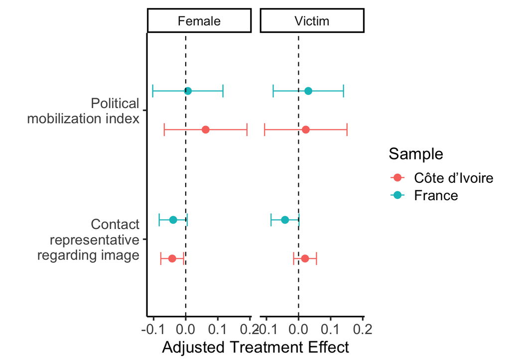

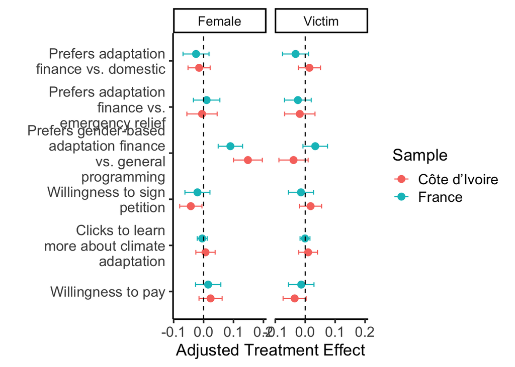